# Jóvenes que no estudian ni trabajan en el Perú, 2015-2025

- Mostrar todo el código
- Ocultar todo el código
- Ver el código fuente

Trabajo final · Fundamentos de R · Diplomatura de Especialización en Ciencia de Datos para las CCSS y Gestión Pública

Autor/a

Grupo 7: Luis Guevara, Rodrigo Norabuena y Marco Virú

Fecha de publicación

5 de octubre de 2026

**Paquetes, paleta de colores y funciones auxiliares**

```r
library(tidyverse)  # dplyr, tidyr, ggplot2, purrr, stringr, forcats
library(haven)      # leer archivos .dta (Stata) del INEI
library(srvyr)      # estimaciones con el diseño muestral, con sintaxis tidyverse
library(gt)         # tablas con formato legible
library(scales)     # formato de ejes

options(survey.lonely.psu = "adjust")

# Paleta de Okabe e Ito, diseñada para ser distinguible bajo las formas más comunes
# de daltonismo. Son los valores exactos que publican los autores y que R trae en
# palette.colors(palette = "Okabe-Ito"); no se inventa ningún tono intermedio.
col_azul       <- "#0072B2"  # azul       — categoría principal y líneas de serie
col_naranja    <- "#D55E00"  # bermellón  — categoría de contraste y resaltados
col_azul_claro <- "#56B4E9"  # azul cielo — relleno de las bandas de confianza
col_gris       <- "#999999"  # gris       — serie de referencia y eje

# Tintas de texto y grilla: son cromo del gráfico, no categorías de datos, así que
# se mantienen fuera de la paleta de Okabe e Ito.
tinta          <- "#0b0b0b"
tinta_2        <- "#52514e"
tinta_3        <- "#898781"
grilla         <- "#e1e0d9"

theme_set(
  theme_minimal(base_size = 12) +
    theme(
      plot.title            = element_text(face = "bold", color = tinta, size = 13),
      plot.subtitle         = element_text(color = tinta_2, margin = margin(b = 10)),
      plot.caption          = element_text(color = tinta_3, hjust = 0, size = 8.5),
      plot.title.position   = "plot",
      plot.caption.position = "plot",
      axis.title            = element_text(color = tinta_2, size = 10),
      axis.text             = element_text(color = tinta_2),
      panel.grid.major.y    = element_line(color = grilla, linewidth = 0.3),
      panel.grid.major.x    = element_blank(),
      panel.grid.minor      = element_blank(),
      axis.line.x           = element_line(color = col_gris, linewidth = 0.3),
      legend.position       = "top",
      legend.justification  = "left",
      legend.title          = element_blank(),
      legend.text           = element_text(color = tinta_2),
      strip.text            = element_text(face = "bold", color = tinta, hjust = 0)
    )
)

fuente <- "Fuente: INEI, ENAHO 2014-2025 (módulos 02, 03 y 05). Elaboración propia."

# Formato de números en el texto: coma decimal y espacio para miles
f1 <- function(x) format(round(x, 1), nsmall = 1, decimal.mark = ",", big.mark = " ")
f0 <- function(x) format(round(x), big.mark = " ", scientific = FALSE)
f2 <- function(x) format(round(x, 2), nsmall = 2, decimal.mark = ",")
f_mill <- function(miles) f2(miles / 1000)   # de miles a millones con 2 decimales
# Valores p en formato APA: sin cero a la izquierda, porque no pueden superar 1
fp <- function(p) {
  if (p < 0.001) "< ,001"
  else sub("^0", "", format(round(p, 3), nsmall = 3, decimal.mark = ","))
}
etiqueta_pct <- label_number(accuracy = 0.1, decimal.mark = ",", suffix = "%")

# Estilo común para todas las tablas gt
estilo_gt <- function(tabla) {
  tabla |>
    tab_options(
      table.font.size            = px(13),
      heading.align              = "left",
      heading.title.font.size    = px(15),
      heading.subtitle.font.size = px(13),
      column_labels.font.weight  = "bold",
      row_group.font.weight      = "bold",
      source_notes.font.size     = px(11),
      data_row.padding           = px(4),
      table.width                = pct(100)
    ) |>
    opt_row_striping()
}
```

# 1 Introducción y pregunta de investigación

Un joven **nini** —*ni estudia ni trabaja*— es alguien que, estando en edad de formarse o de  
producir, no hace ninguna de las dos cosas. No es lo mismo que estar desempleado: el desempleado  
busca trabajo activamente, mientras que buena parte de los ninis está fuera de la fuerza laboral,  
muchas veces por responsabilidades de cuidado en el hogar. Tampoco es una categoría homogénea,  
y ahí está justamente lo interesante del problema.

Importa por dos razones. La primera es individual: los períodos prolongados de inactividad en la juventud  
dejan cicatrices en los ingresos y en la empleabilidad futura. Székely & Karver (2021) siguen cohortes  
sintéticas construidas con 234 encuestas de hogares de 18 países de la región y estiman que **un**  
**punto porcentual más en la proporción de ninis de una cohorte de 15 a 20 años se asocia con salarios**  
**7,7 % más bajos entre los varones y 3,0 % más bajos entre las mujeres** cuando esa misma cohorte  
llega a los 35 a 40 años. Entre las mujeres, además, cae la probabilidad de estar empleada, efecto que  
no aparece entre los varones. Conviene subrayar que la estimación es a nivel de cohorte, no  
individual: no dice cuánto pierde una persona por haber sido nini, sino cuánto pierde la generación  
a la que pertenece. Para dimensionar el fenómeno, de Hoyos et al. (2016) estiman que hay unos 20 millones de  
ninis de 15 a 24 años en América Latina, de los cuales el 66 % son mujeres. La segunda razón es  
agregada: se trata de capacidad productiva que el país no está utilizando. La comunidad internacional lo  
reconoció al incorporarlo como indicador 8.6.1 de los Objetivos de Desarrollo Sostenible  
(Naciones Unidas, 2015).

En el caso peruano hay un rasgo del mercado laboral que condiciona cómo debe leerse este indicador.  
Asencios et al. (2025) documentan que, desde 2005, la tasa de participación y la PEA ocupada se mueven  
casi en paralelo: cuando la participación sube, quienes entran a la fuerza laboral terminan  
mayoritariamente ocupados y no desempleados. La explicación más plausible es el tamaño del sector  
informal, que absorbe a los nuevos entrantes: la informalidad laboral lleva más de una década  
instalada en torno al 72 % de la PEA ocupada y en 2023 todavía alcanzaba el **71,1 %**  
(Asencios et al., 2025). **Esto importa para interpretar nuestros resultados:**  
En un mercado que absorbe casi todo lo que entra, quedarse fuera no se manifiesta como desempleo  
sino como inactividad, y es exactamente lo que encontramos en la sección Sección 4.5.

La condición tampoco es un estado fijo. Chacaltana & Ruiz (2012) muestran que la juventud es un período  
de transiciones —de la escuela al trabajo, a la maternidad o paternidad, a la migración— y que son  
esas transiciones, más que un atributo permanente, determinan el acceso a un empleo decente.  
Con la Encuesta Nacional de la Juventud de 2011 estimaban que el 16 % de los jóvenes peruanos no  
trabajaba ni asistía a un centro educativo, una referencia útil porque antecede a nuestra serie.

Tokman (2010) agrega el matiz que más nos interesa: dentro de ese grupo, los más expuestos son  
quienes no accedieron a una educación de calidad, porque quedan ante una disyuntiva entre el  
desempleo y un empleo sin derechos laborales. Es una hipótesis contrastable con nuestros datos, y la  
ponemos a prueba en la sección Sección 4.4.

Conviene advertir que circulan estimaciones dispares sobre la magnitud actual. El Instituto Peruano de Economía (2024) cifró  
en 1,2 millones los jóvenes de 15 a 29 años en esta condición hacia agosto de 2024, unos 300 mil más  
que en 2019. Nuestra estimación para ese año es sensiblemente mayor y el aumento desde 2019 es bastante menor (Tabla 6). La diferencia **no puede reconciliarse** porque esa publicación no documenta ni la encuesta ni el período de referencia que emplea. Lo señalamos para que quede claro de dónde proviene cada cifra: la nuestra proviene de la ENAHO, con la definición operativa y el diseño muestral que se detallan más adelante.

Sobre el **mecanismo**, en cambio, sí coincidimos. Esa publicación atribuye el aumento a una caída de  
la participación laboral juvenil y no a un alza del desempleo: no solo habría más jóvenes que no  
estudian ni trabajan, sino que la mayoría tampoco busca empleo, a que allí se denomina *nininis*.  
Nuestros datos apuntan en la misma dirección y permiten cuantificarlo (Sección 4.5).

Este reporte responde una pregunta:

> **¿Cómo evolucionó la proporción de jóvenes peruanos de 15 a 29 años que no estudian ni trabajan entre 2015 y 2025, y en qué grupos se concentra esta condición?**

El rango de 15 a 29 años no es arbitrario: es el que define como *joven* la Ley N.º 27802, Ley del Consejo Nacional de la Juventud (Congreso de la República del Perú, 2002). El indicador de los ODS usa en cambio el tramo de 15 a 24 años, que reportamos como análisis de robustez para permitir comparación internacional.

Antes de mirar los datos, cuatro expectativas que luego contrastamos:

1. La proporción debería mostrar una **mejora lenta** entre 2015 y 2019, acompañando el crecimiento económico del período.
2. **2020 debería romper la serie** por el cierre de centros educativos y la destrucción de empleo durante la pandemia.
3. La condición debería ser **marcadamente más frecuente entre las mujeres**, por la distribución desigual del trabajo doméstico y de cuidados.
4. Debería existir un **gradiente educativo**: a menor nivel alcanzado, mayor incidencia.

Responderla toma cuatro pasos, que ocupan el resto del documento. Primero se **descargan** los microdatos del portal del INEI: los módulos 102, 103 y 105 de cada año —características de los miembros del hogar, educación y empleo—, más el 104 de salud, que se baja por completitud aunque este análisis no lo use. Segundo, se **audita la codificación** de cada variable leyendo las etiquetas de valores embebidas en los propios archivos, para comprobar que signifiquen lo mismo en los doce años. Tercero, se **limpian y unen** los módulos en una sola base de personas. Cuarto, se construye el indicador y se analiza su evolución y su concentración por grupos.

# 2 Datos

## 2.1 Fuente

Los datos provienen de la **Encuesta Nacional de Hogares (ENAHO)**, metodología actualizada, que ejecuta el Instituto Nacional de Estadística e Informática del Perú (2026). Es la encuesta oficial con la que el país mide pobreza, empleo y condiciones de vida; se levanta de forma continua desde mayo de 2003 y su muestra es probabilística, de áreas, estratificada y bietápica, con un nivel de confianza del 95 %, según su ficha técnica (2025).

- **Institución que la produce:** Instituto Nacional de Estadística e Informática (INEI), Perú.
- **Período analizado:** 2014 a 2025. El titular del reporte es 2015-2025; 2014 entra como año de contexto previo a la serie.
- **Unidad de análisis:** **la persona** residente habitual de un hogar particular. Cada fila de la base final es una persona entrevistada en un año determinado.
- **Cobertura:** nacional, urbana y rural, los 24 departamentos y la Provincia Constitucional del Callao. Se excluye a quienes viven en viviendas colectivas y a los miembros de las fuerzas armadas que viven en cuarteles.
- **Descarga:** `https://proyectos.inei.gob.pe/microdatos/`

Los archivos se descargan con `scripts/01_descargar_enaho.R`, que recorre los 12 años y los 4 módulos y guarda cada ZIP en `data/raw/<año>/`. Son 48 archivos y unos 693 MB. Este es su núcleo:

**Descarga de los microdatos (no se ejecuta al compilar)**

```r
# Códigos de encuesta que el INEI asigna a cada año de la ENAHO anual
codigos_enaho <- c(440, 498, 546, 603, 634, 687, 737, 759, 784, 906, 966, 1031)
anios <- 2014:2025

for (i in seq_along(anios)) {
  for (modulo in c("02", "03", "04", "05")) {
    archivo <- paste0(codigos_enaho[i], "-Modulo", modulo, ".zip")
    url <- paste0("https://proyectos.inei.gob.pe/iinei/srienaho/descarga/STATA/", archivo)
    destino <- file.path("data/raw", anios[i], archivo)
    if (!file.exists(destino)) download.file(url, destino, mode = "wb")
  }
}
```

Usamos tres de los cuatro módulos descargados. Cada uno tiene su propio universo, y eso condiciona quién puede entrar al análisis:

| Módulo | Archivo | Universo | Qué aporta |
| --- | --- | --- | --- |
| 200 | `enaho01-<año>-200.dta` | Miembros del hogar | Edad, sexo, parentesco, residencia, geografía |
| 300 | `enaho01a-<año>-300.dta` | Personas de 3 años y más | Matrícula y asistencia → **estudia** |
| 500 | `enaho01a-<año>-500.dta` | Personas de 14 años y más | Condición de actividad → **trabaja** |

El módulo 04 (Salud) se descarga pero no se usa en este análisis.

## 2.2 Variables principales

**Ver código**

```r
gt_variables <- tribble(
  ~Módulo, ~Variable, ~Descripción,
  "200", "conglome, vivienda, hogar, codperso", "Llave que identifica a cada persona",
  "200", "mes",       "Mes de la entrevista",
  "200", "ubigeo",    "Ubicación geográfica; los 2 primeros dígitos son el departamento",
  "200", "dominio",   "Dominio geográfico: región natural y Lima Metropolitana",
  "200", "estrato",   "Estrato geográfico, del que se deriva el área urbana o rural",
  "200", "p203",      "Relación de parentesco con el jefe o jefa del hogar",
  "200", "p204, p205, p206", "Condición de residente habitual del hogar",
  "200", "p207",      "Sexo",
  "200", "p208a",     "Edad en años cumplidos",
  "200", "p209",      "Estado civil o conyugal",
  "300", "p301a",     "Último nivel educativo aprobado",
  "300", "p306",      "¿Está matriculado en el presente año?",
  "300", "p307",      "¿Asiste actualmente a un centro de enseñanza?",
  "300", "p313",      "Razón principal para no estudiar",
  "300", "t313a",     "Razón para no estudiar, recodificada por el INEI (incluye motivos de COVID-19)",
  "500", "ocu500",    "Indicador de la PEA: ocupado, desocupado abierto, desocupado oculto o no PEA",
  "500", "p545",      "¿Hizo algo para conseguir trabajo la semana pasada?",
  "500", "p546",      "¿Qué estuvo haciendo la semana pasada?",
  "500", "p547",      "¿Deseaba trabajar?",
  "500", "fac500a",   "Factor de expansión de empleo (población de 14 años y más)"
) |>
  gt(groupname_col = "Módulo") |>
  tab_source_note(paste("Nota.", "ENAHO 2014-2025, módulos de miembros del hogar, educación y empleo.")) |>
  tab_source_note("La codificación completa de cada variable, verificada año por año, está en docs/diccionario_variables.md.") |>
  estilo_gt()
gt_variables
```

Tabla 1: Variables utilizadas, por módulo de origen

| Variable | Descripción |
| --- | --- |
| 200 |  |
| conglome, vivienda, hogar, codperso | Llave que identifica a cada persona |
| mes | Mes de la entrevista |
| ubigeo | Ubicación geográfica; los 2 primeros dígitos son el departamento |
| dominio | Dominio geográfico: región natural y Lima Metropolitana |
| estrato | Estrato geográfico, del que se deriva el área urbana o rural |
| p203 | Relación de parentesco con el jefe o jefa del hogar |
| p204, p205, p206 | Condición de residente habitual del hogar |
| p207 | Sexo |
| p208a | Edad en años cumplidos |
| p209 | Estado civil o conyugal |
| 300 |  |
| p301a | Último nivel educativo aprobado |
| p306 | ¿Está matriculado en el presente año? |
| p307 | ¿Asiste actualmente a un centro de enseñanza? |
| p313 | Razón principal para no estudiar |
| t313a | Razón para no estudiar, recodificada por el INEI (incluye motivos de COVID-19) |
| 500 |  |
| ocu500 | Indicador de la PEA: ocupado, desocupado abierto, desocupado oculto o no PEA |
| p545 | ¿Hizo algo para conseguir trabajo la semana pasada? |
| p546 | ¿Qué estuvo haciendo la semana pasada? |
| p547 | ¿Deseaba trabajar? |
| fac500a | Factor de expansión de empleo (población de 14 años y más) |

Nota. ENAHO 2014-2025, módulos de miembros del hogar, educación y empleo.  
La codificación completa de cada variable, verificada año por año, está en docs/diccionario_variables.md.

## 2.3 Definición operativa

Clasificamos como **nini** a la persona de 15 a 29 años, residente habitual del hogar, que cumple las dos condiciones a la vez:

1. **No estudia.** No está matriculada en el año en curso o, estándolo, no asiste actualmente (`p306 ≠ 1` o `p307 ≠ 1`). Con una corrección por vacaciones escolares que explicamos en la sección Sección 3.8.
2. **No trabaja.** No está ocupada según el indicador oficial de la PEA (`ocu500 ≠ 1`). Esta definición de ocupado es la del INEI, que a su vez sigue a la Organización Internacional del Trabajo (1982): incluye a quienes trabajaron al menos una hora en la semana de referencia, a los ausentes temporales con empleo al que volverán, y a los trabajadores familiares no remunerados con 15 horas o más.

Nótese que **el nini no es el desempleado**. El desempleado está en la PEA y busca trabajo; el nini abarca tanto a los desocupados como a los inactivos. La distinción es central para interpretar los resultados, y la retomamos en la sección Sección 4.5.

# 3 Preprocesamiento y limpieza

## 3.1 Importación desde los archivos comprimidos

Leer estos datos tiene tres dificultades prácticas que conviene nombrar, porque condicionan todo el código que sigue.

La primera es el **tamaño**. El módulo de empleo de 2025 ocupa 909 MB descomprimido y tiene 1 413 columnas, porque ese año el INEI pasó del formato Stata 113 al 118, que reserva cuatro bytes por carácter. Leer el archivo completo no es viable en una computadora normal, así que **seleccionamos las columnas al leer**. No es una optimización: sin eso el proceso no corre.

La segunda es que **la estructura interna de los ZIP no es consistente**. Lo habitual es encontrar el archivo dentro de una carpeta con el nombre del ZIP (`440-Modulo02/enaho01-2014-200.dta`), pero 2015 usa guion bajo en el módulo 02 (`498_Modulo02/`) y en el módulo 03 deja el archivo directamente en la raíz. Por eso el patrón de búsqueda se ancla al **nombre del archivo**, no a la carpeta.

La tercera es que **hay archivos que no son los que buscamos**: tablas auxiliares de clasificadores (`enaho_tabla_ciuo_88.dta`), complementarios (`enaho01a-2014-300a.dta`) y, en 2015, un duplicado del módulo 500 con guion bajo (`enaho01a-2015_500.dta`). Una búsqueda por `*.dta` traería entre dos y cinco archivos por ZIP.

**Lectura de los 36 archivos .dta desde los ZIP, con caché**

```r
anios  <- 2014:2025
llaves <- c("conglome", "vivienda", "hogar", "codperso")

codigos_enaho <- c("2014" = "440", "2015" = "498", "2016" = "546", "2017" = "603",
                   "2018" = "634", "2019" = "687", "2020" = "737", "2021" = "759",
                   "2022" = "784", "2023" = "906", "2024" = "966", "2025" = "1031")

# Solo las columnas que el análisis necesita. Ver docs/diccionario_variables.md.
vars_modulo <- list(
  "200" = c(llaves, "mes", "ubigeo", "dominio", "estrato",
            "p203", "p204", "p205", "p206", "p207", "p208a", "p209", "facpob07"),
  "300" = c(llaves, "p301a", "p306", "p307", "p313", "t313a"),
  "500" = c(llaves, "ocu500", "p545", "p546", "p547", "fac500a")
)

leer_modulo <- function(anio, modulo) {

  codigo <- codigos_enaho[[as.character(anio)]]
  zipf   <- file.path("data/raw", anio, sprintf("%s-Modulo%02d.zip", codigo, modulo %/% 100))
  stopifnot("No se encuentra el ZIP" = file.exists(zipf))

  # Patrón anclado al nombre de archivo: la carpeta interna cambia entre años, y a
  # veces no hay carpeta. El guion antes del módulo descarta el duplicado de 2015
  # (enaho01a-2015_500.dta) y el "$" descarta los complementarios (...-300a.dta).
  # useBytes evita que los nombres en latin1 de 2014 rompan el grep.
  entradas <- unzip(zipf, list = TRUE)$Name
  objetivo <- grep(sprintf("(^|/)enaho01a?-%s-%s[.]dta$", anio, modulo),
                   entradas, value = TRUE, ignore.case = TRUE, useBytes = TRUE)
  stopifnot("El .dta debe resolverse a exactamente un archivo" = length(objetivo) == 1)

  # haven::read_dta() admite leer desde una conexión unz(), pero col_select NO
  # funciona sobre una conexión: hay que descomprimir a un temporal y leer de ahí.
  tmp <- file.path(tempdir(), paste0("enaho_", anio, "_", modulo))
  dir.create(tmp, showWarnings = FALSE, recursive = TRUE)
  on.exit(unlink(tmp, recursive = TRUE), add = TRUE)
  unzip(zipf, files = objetivo, exdir = tmp, junkpaths = TRUE)

  datos <- read_dta(file.path(tmp, basename(objetivo)),
                    col_select = any_of(vars_modulo[[as.character(modulo)]]))

  # Guardamos el diccionario de etiquetas de Stata ANTES de aplanarlo. Esa tabla es
  # la evidencia de que los códigos significan lo mismo en los 12 años (sección 3.3)
  # y la usamos para recodificar por texto en vez de por número.
  etiquetas <- tibble(
    anio = anio, modulo = modulo, variable = names(datos),
    clase = map_chr(datos, \(x) class(x)[1]),
    etiquetas = map_chr(datos, function(x) {
      e <- attr(x, "labels")
      if (is.null(e)) NA_character_ else paste0(e, " = ", names(e), collapse = "; ")
    })
  )

  list(
    # El año se inyecta desde la carpeta: la columna original del INEI se llama
    # "aÑo", con eñe mayúscula, y es una fuente segura de problemas.
    datos     = datos |> zap_labels() |> zap_formats() |> mutate(anio = anio, .before = 1),
    etiquetas = etiquetas
  )
}

# Caché invalidado por hash de la configuración: si cambian los años o la lista de
# variables, el extracto se regenera. Comprobar solo file.exists() haría que el
# reporte compilara datos viejos en silencio.
config     <- list(anios = anios, modulos = c(200, 300, 500), vars = vars_modulo)
hash_config <- rlang::hash(config)
ruta_cache <- "data/processed/enaho_extracto.rds"

cache_valido <- file.exists(ruta_cache) &&
  identical(readRDS(ruta_cache)$hash, hash_config)

if (!cache_valido) {
  dir.create("data/processed", showWarnings = FALSE, recursive = TRUE)
  lecturas <- expand_grid(anio = anios, modulo = c(200, 300, 500)) |>
    mutate(resultado = map2(anio, modulo, leer_modulo))
  unir <- function(m) {
    lecturas |> filter(modulo == m) |> pull(resultado) |> map("datos") |> bind_rows()
  }
  crudo <- list(
    hash      = hash_config,
    m200      = unir(200), m300 = unir(300), m500 = unir(500),
    etiquetas = lecturas$resultado |> map("etiquetas") |> bind_rows()
  )
  saveRDS(crudo, ruta_cache, compress = "xz")
}

crudo <- readRDS(ruta_cache)
```

La lectura completa de los 36 archivos toma alrededor de 40 segundos y produce un extracto de unos 10 MB, que queda cacheado para las compilaciones siguientes.

## 3.2 Diagnóstico de los datos crudos

**Ver código**

```r
llaves_anio <- c("anio", llaves)

diagnostico <- list(`Módulo 200` = crudo$m200,
                    `Módulo 300` = crudo$m300,
                    `Módulo 500` = crudo$m500) |>
  imap(\(d, nombre) d |> group_by(anio) |>
         summarise(filas = n(),
                   duplicados = sum(duplicated(pick(all_of(llaves)))),
                   .groups = "drop") |>
         mutate(modulo = nombre)) |>
  bind_rows() |>
  pivot_wider(names_from = modulo, values_from = c(filas, duplicados))

total_duplicados <- diagnostico |> select(starts_with("duplicados")) |> sum()

gt_diagnostico <- diagnostico |>
  select(anio, starts_with("filas"), starts_with("duplicados")) |>
  gt() |>
  tab_source_note(paste("Nota.", "Filas leídas y duplicados sobre la llave conglome-vivienda-hogar-codperso.")) |>
  tab_spanner(label = "Filas", columns = starts_with("filas")) |>
  tab_spanner(label = "Duplicados", columns = starts_with("duplicados")) |>
  cols_label(anio = "Año",
             `filas_Módulo 200` = "200", `filas_Módulo 300` = "300", `filas_Módulo 500` = "500",
             `duplicados_Módulo 200` = "200", `duplicados_Módulo 300` = "300",
             `duplicados_Módulo 500` = "500") |>
  fmt_number(columns = starts_with("filas"), decimals = 0, sep_mark = " ") |>
  grand_summary_rows(columns = starts_with("filas"), fns = list(Total = ~ sum(.)),
                     fmt = ~ fmt_number(., decimals = 0, sep_mark = " ")) |>
  tab_source_note(fuente) |>
  estilo_gt()
gt_diagnostico
```

Tabla 2: Tamaño de cada módulo y duplicados sobre la llave de persona

|  | Año | Filas 200 | Filas 300 | Filas 500 | Duplicados 200 | Duplicados 300 | Duplicados 500 |
| --- | --- | --- | --- | --- | --- | --- | --- |
|  | 2014 | 124 154 | 111 741 | 87 871 | 0 | 0 | 0 |
|  | 2015 | 127 474 | 113 605 | 88 084 | 0 | 0 | 0 |
|  | 2016 | 138 427 | 125 139 | 97 422 | 0 | 0 | 0 |
|  | 2017 | 132 657 | 119 188 | 93 185 | 0 | 0 | 0 |
|  | 2018 | 139 657 | 126 761 | 99 646 | 0 | 0 | 0 |
|  | 2019 | 128 276 | 116 590 | 92 094 | 0 | 0 | 0 |
|  | 2020 | 126 831 | 115 777 | 91 315 | 0 | 0 | 0 |
|  | 2021 | 121 067 | 109 867 | 86 806 | 0 | 0 | 0 |
|  | 2022 | 121 253 | 110 257 | 87 661 | 0 | 0 | 0 |
|  | 2023 | 119 747 | 108 354 | 86 654 | 0 | 0 | 0 |
|  | 2024 | 117 721 | 106 619 | 85 992 | 0 | 0 | 0 |
|  | 2025 | 115 145 | 104 446 | 84 853 | 0 | 0 | 0 |
| Total | — | 1 512 409 | 1 368 344 | 1 081 583 | — | — | — |

Nota. Filas leídas y duplicados sobre la llave conglome-vivienda-hogar-codperso.  
Fuente: INEI, ENAHO 2014-2025 (módulos 02, 03 y 05). Elaboración propia.

**Lectura.** No hay un solo registro duplicado sobre la llave de persona en ninguno de los 36 archivos (0 en total). Es un buen punto de partida: podemos unir los módulos sin riesgo de multiplicar filas.

Los problemas que sí encontramos, y cómo los resolvimos:

1. **Nombres de variable poco claros.** Los nombres siguen la numeración del cuestionario (`p208a`, `ocu500`), no el concepto. Peor: la primera columna de cada archivo se llama `aÑo`, con eñe mayúscula, lo que obliga a comillas invertidas en cualquier `select()`. Preferimos **no leerla** e inyectar el año desde el nombre de la carpeta.
2. **Tipos de datos.** `mes`, `conglome`, `vivienda`, `hogar`, `codperso` y `ubigeo` vienen como texto con ceros a la izquierda significativos (`conglome = "0002"`). Convertirlos a número rompe los cruces, así que se conservan como texto; solo `mes` se convierte a entero, porque lo usamos para ordenar.
3. **Etiquetas de Stata inconsistentes entre años.** Se guardan antes de aplanarlas y se analizan en la sección siguiente.
4. **`ocu500` tiene valores 0 no documentados.** El diccionario del INEI solo define los códigos 1 a
   4. Los ceros se tratan como valores perdidos y se cuentan explícitamente.
5. **Valores perdidos estructurales.** No son errores: `p307` solo se pregunta a quienes declararon estar matriculados, `p313` solo a quienes no estudian, y `p546` solo a quienes no trabajaron ni buscaron trabajo. Cada regla se maneja de forma explícita al construir los indicadores.

## 3.3 ¿Significan lo mismo las variables en los doce años?

Una serie de once años solo es comparable si los códigos significan lo mismo en todos. No lo dimos por supuesto: auditamos las etiquetas de Stata de los 36 archivos.

**Auditoría de la codificación año por año**

```r
# Normalizar para comparar textos sin que estorben mayúsculas, tildes o puntuación
normalizar <- function(x) {
  x |> str_to_lower() |> iconv(to = "ASCII//TRANSLIT") |>
    str_replace_all("[^a-z0-9 ]", " ") |> str_squish()
}

# Pasa de "1 = Ocupado; 2 = Desocupado abierto" a una fila por código
etiquetas_largo <- crudo$etiquetas |>
  filter(!is.na(etiquetas)) |>
  separate_longer_delim(etiquetas, delim = "; ") |>
  mutate(codigo = as.integer(str_extract(etiquetas, "^[^=]+(?= = )")),
         texto  = str_remove(etiquetas, "^[^=]+ = "),
         texto_norm = normalizar(texto))

estabilidad <- etiquetas_largo |>
  arrange(variable, anio, codigo) |>
  group_by(variable, anio) |>
  summarise(firma   = paste0(codigo, "=", texto_norm, collapse = "|"),
            codigos = paste(sort(unique(codigo)), collapse = ","),
            .groups = "drop") |>
  group_by(variable) |>
  summarise(versiones = n_distinct(firma), sets = n_distinct(codigos), .groups = "drop") |>
  mutate(diagnostico = case_when(
    versiones == 1 ~ "Idéntica en los 12 años",
    sets == 1      ~ "Solo cambia la redacción; los códigos son los mismos",
    TRUE           ~ "Aparecen códigos nuevos a mitad de la serie"
  ))

n_identicas <- sum(estabilidad$diagnostico == "Idéntica en los 12 años")

gt_etiquetas <- estabilidad |>
  arrange(desc(versiones), variable) |>
  select(variable, versiones, diagnostico) |>
  gt() |>
  tab_source_note(paste("Nota.", "Resultado de comparar las etiquetas de Stata de los 36 archivos.")) |>
  cols_label(variable = "Variable", versiones = "Versiones de etiqueta",
             diagnostico = "Diagnóstico") |>
  tab_style(style = cell_text(weight = "bold"),
            locations = cells_body(columns = variable,
                                   rows = variable %in% c("ocu500", "p306", "p307"))) |>
  tab_source_note("Las versiones se cuentan ignorando mayúsculas, tildes y puntuación: solo se reportan diferencias reales de redacción.") |>
  estilo_gt()
gt_etiquetas
```

Tabla 3: Estabilidad de la codificación de las variables entre 2014 y 2025

| Variable | Versiones de etiqueta | Diagnóstico |
| --- | --- | --- |
| p301a | 6 | Aparecen códigos nuevos a mitad de la serie |
| t313a | 4 | Aparecen códigos nuevos a mitad de la serie |
| estrato | 3 | Solo cambia la redacción; los códigos son los mismos |
| p313 | 3 | Solo cambia la redacción; los códigos son los mismos |
| p546 | 3 | Solo cambia la redacción; los códigos son los mismos |
| p203 | 2 | Aparecen códigos nuevos a mitad de la serie |
| dominio | 1 | Idéntica en los 12 años |
| ocu500 | 1 | Idéntica en los 12 años |
| p204 | 1 | Idéntica en los 12 años |
| p205 | 1 | Idéntica en los 12 años |
| p206 | 1 | Idéntica en los 12 años |
| p207 | 1 | Idéntica en los 12 años |
| p209 | 1 | Idéntica en los 12 años |
| p306 | 1 | Idéntica en los 12 años |
| p307 | 1 | Idéntica en los 12 años |
| p545 | 1 | Idéntica en los 12 años |
| p547 | 1 | Idéntica en los 12 años |

Nota. Resultado de comparar las etiquetas de Stata de los 36 archivos.  
Las versiones se cuentan ignorando mayúsculas, tildes y puntuación: solo se reportan diferencias reales de redacción.

**Lectura.** De las 17 variables con etiquetas, 11 son idénticas en los doce años. Entre ellas están las tres que definen el indicador: **`ocu500`, `p306` y `p307`**. Es el resultado más importante de esta auditoría, porque significa que la serie se puede construir sin ningún ajuste de armonización.

Como protección adicional, **no recodificamos por número sino por texto de etiqueta**. Si el INEI renumerara una categoría, el reporte fallaría de forma ruidosa en lugar de asignar mal en silencio:

**Buscar categorías por su etiqueta, no por su número**

```r
# Devuelve el código asociado a una etiqueta, verificando que sea el mismo en todos
# los años y que el patrón identifique exactamente una categoría por año.
codigo_de <- function(variable_, patron) {
  coincidencias <- etiquetas_largo |>
    filter(variable == variable_, str_detect(texto_norm, patron))
  por_anio <- coincidencias |> count(anio)
  stopifnot(
    "El patrón debe coincidir en todos los años"       = nrow(por_anio) == length(anios),
    "El patrón debe coincidir con una sola categoría"  = all(por_anio$n == 1),
    "El código debe ser el mismo en todos los años"    = n_distinct(coincidencias$codigo) == 1
  )
  unique(coincidencias$codigo)
}

cod_vacaciones <- codigo_de("p313",   "^de vacaciones$")
cod_quehaceres <- codigo_de("p546",   "quehaceres del hogar")
cod_estudiando <- codigo_de("p546",   "^estudiando$")
cod_enfermo    <- codigo_de("p546",   "enfermo o incapacitado")
cod_pension    <- codigo_de("p546",   "pension o jubilacion")
cod_ocupado    <- codigo_de("ocu500", "^ocupado$")
```

## 3.4 Unión de los módulos

**Unión de los tres módulos por la llave de persona**

```r
# El módulo 200 es la base: contiene a todas las personas del hogar. Los otros dos
# entran con left_join para no perder a nadie por el camino.
base <- crudo$m200 |>
  left_join(crudo$m300, by = llaves_anio) |>
  left_join(crudo$m500, by = llaves_anio)

# Validaciones: el merge no debe crear filas, y ningún registro de los módulos 300
# o 500 debería quedar huérfano respecto del 200.
stopifnot("El merge duplicó filas" = nrow(base) == nrow(crudo$m200))
huerfanos_300 <- nrow(anti_join(crudo$m300, crudo$m200, by = llaves_anio))
huerfanos_500 <- nrow(anti_join(crudo$m500, crudo$m200, by = llaves_anio))
stopifnot("Hay registros huérfanos" = huerfanos_300 == 0 && huerfanos_500 == 0)
```

La base resultante tiene 1 512 409 filas, una por persona y año, sin registros huérfanos en ninguno de los dos módulos secundarios.

## 3.5 Filtros y valores perdidos

**Universo del análisis y tratamiento de valores perdidos**

```r
base <- base |>
  mutate(
    mes = as.integer(mes),
    # Residente habitual, según la definición de la ficha técnica del INEI: es
    # miembro del hogar y no está ausente 30 días o más, o bien no es miembro pero
    # está presente 30 días o más. coalesce() evita que un NA se cuele como TRUE.
    residente = coalesce((p204 == 1 & p205 == 2) | (p204 == 2 & p206 == 1), FALSE)
  )

jovenes_todos <- base |> filter(residente, between(p208a, 15, 29))

# Recuento explícito de cada motivo de exclusión, antes de aplicarlos
perdidos <- tibble(
  Motivo = c("Sin registro en el módulo de educación (p306 vacío)",
             "Sin registro en el módulo de empleo (ocu500 vacío)",
             "ocu500 con valor 0, no documentado por el INEI",
             "Sin factor de expansión de empleo (fac500a vacío)"),
  Casos = c(sum(is.na(jovenes_todos$p306)),
            sum(is.na(jovenes_todos$ocu500)),
            sum(jovenes_todos$ocu500 == 0, na.rm = TRUE),
            sum(is.na(jovenes_todos$fac500a)))
) |>
  mutate(`% del total` = 100 * Casos / nrow(jovenes_todos))

jovenes <- jovenes_todos |>
  filter(!is.na(p306), !is.na(ocu500), ocu500 != 0, !is.na(fac500a))
```

**Ver código**

```r
gt_perdidos <- perdidos |>
  gt() |>
  tab_source_note(paste("Nota.", paste0("Sobre ", f0(nrow(jovenes_todos)),
                               " residentes habituales de 15 a 29 años, 2014-2025"))) |>
  fmt_number(columns = Casos, decimals = 0, sep_mark = " ") |>
  fmt_number(columns = `% del total`, decimals = 2, dec_mark = ",") |>
  tab_source_note(fuente) |>
  estilo_gt()
gt_perdidos
```

Tabla 4: Valores perdidos entre los jóvenes de 15 a 29 años

| Motivo | Casos | % del total |
| --- | --- | --- |
| Sin registro en el módulo de educación (p306 vacío) | 354 | 0,12 |
| Sin registro en el módulo de empleo (ocu500 vacío) | 0 | 0,00 |
| ocu500 con valor 0, no documentado por el INEI | 615 | 0,20 |
| Sin factor de expansión de empleo (fac500a vacío) | 0 | 0,00 |

Nota. Sobre 306 576 residentes habituales de 15 a 29 años, 2014-2025  
Fuente: INEI, ENAHO 2014-2025 (módulos 02, 03 y 05). Elaboración propia.

**Lectura.** Las pérdidas son marginales: en conjunto se excluye menos del 0,4 % de los jóvenes. El caso más llamativo son los 615 registros con `ocu500 = 0`, un valor que el diccionario del INEI no documenta y que aparece de forma dispersa en todos los años. Al no poder interpretarlo, lo tratamos como perdido; su peso es demasiado pequeño para alterar cualquier conclusión.

## 3.6 Recodificación

**Construcción de la variable nini y de las variables de corte**

```r
departamentos <- c(
  "01" = "Amazonas", "02" = "Áncash", "03" = "Apurímac", "04" = "Arequipa",
  "05" = "Ayacucho", "06" = "Cajamarca", "07" = "Callao", "08" = "Cusco",
  "09" = "Huancavelica", "10" = "Huánuco", "11" = "Ica", "12" = "Junín",
  "13" = "La Libertad", "14" = "Lambayeque", "15" = "Lima", "16" = "Loreto",
  "17" = "Madre de Dios", "18" = "Moquegua", "19" = "Pasco", "20" = "Piura",
  "21" = "Puno", "22" = "San Martín", "23" = "Tacna", "24" = "Tumbes",
  "25" = "Ucayali"
)

jovenes <- jovenes |>
  mutate(
    # --- Variables de diseño muestral -------------------------------------------
    peso             = fac500a,
    estrato_muestral = estrato,

    # --- Características demográficas --------------------------------------------
    sexo = factor(p207, levels = 1:2, labels = c("Hombres", "Mujeres")),
    grupo_edad = cut(p208a, breaks = c(14, 19, 24, 29),
                     labels = c("15 a 19 años", "20 a 24 años", "25 a 29 años")),

    # p301a: los códigos 1 a 10 son idénticos en los 12 años. El 12 (básica especial)
    # aparece desde 2017 y se agrupa con los niveles básicos por su escaso tamaño.
    nivel_educativo = case_when(
      p301a %in% c(1:4, 12) ~ "Primaria o menos",
      p301a == 5            ~ "Secundaria incompleta",
      p301a == 6            ~ "Secundaria completa",
      p301a %in% 7:8        ~ "Superior no universitaria",
      p301a %in% 9:11       ~ "Superior universitaria"
    ) |> factor(levels = c("Primaria o menos", "Secundaria incompleta", "Secundaria completa",
                           "Superior no universitaria", "Superior universitaria")),

    # p203 incorpora el código 11 desde 2018: agrupar en tres categorías lo absorbe.
    parentesco = case_when(
      p203 %in% 1:2 ~ "Jefe(a) o cónyuge",
      p203 == 3     ~ "Hijo(a)",
      TRUE          ~ "Otro familiar o no familiar"
    ),
    estado_civil = case_when(
      p209 == 6     ~ "Soltero(a)",
      p209 %in% 1:2 ~ "Casado(a) o conviviente",
      p209 %in% 3:5 ~ "Separado(a), divorciado(a) o viudo(a)"
    ),

    # --- Geografía ----------------------------------------------------------------
    area = factor(if_else(estrato <= 5, "Urbana", "Rural"), levels = c("Urbana", "Rural")),
    region = case_when(
      dominio == 8     ~ "Lima Metropolitana",
      dominio %in% 1:3 ~ "Resto de la Costa",
      dominio %in% 4:6 ~ "Sierra",
      dominio == 7     ~ "Selva"
    ) |> factor(levels = c("Lima Metropolitana", "Resto de la Costa", "Sierra", "Selva")),
    departamento = unname(departamentos[str_sub(ubigeo, 1, 2)]),

    # --- Indicadores centrales ----------------------------------------------------
    # p307 solo se pregunta a quienes declararon p306 == 1, así que la ausencia de
    # respuesta se interpreta explícitamente como "no asiste".
    estudia_formal = p306 == 1 & coalesce(p307 == 1, FALSE),
    # Corrección de vacaciones escolares (ver sección siguiente)
    de_vacaciones  = coalesce(p313 == cod_vacaciones, FALSE) |
                     coalesce(t313a == cod_vacaciones, FALSE),
    estudia        = estudia_formal | de_vacaciones,
    trabaja        = ocu500 == cod_ocupado,
    nini           = !estudia & !trabaja,

    condicion = case_when(
      estudia & trabaja ~ "Estudia y trabaja",
      estudia           ~ "Solo estudia",
      trabaja           ~ "Solo trabaja",
      TRUE              ~ "No estudia ni trabaja"
    ) |> factor(levels = c("Solo trabaja", "Solo estudia", "Estudia y trabaja",
                           "No estudia ni trabaja")),

    # Qué hace el nini. ocu500 separa primero al desocupado del inactivo; p546 solo
    # clasifica a quien ya quedó fuera de la PEA.
    situacion_nini = case_when(
      !nini               ~ NA_character_,
      ocu500 %in% 2:3     ~ "Desempleado: busca trabajo",
      p546 == cod_quehaceres ~ "Inactivo: quehaceres del hogar",
      p546 == cod_estudiando ~ "Inactivo: estudia fuera del sistema formal",
      p546 == cod_enfermo    ~ "Inactivo: por enfermedad o discapacidad",
      p546 == cod_pension    ~ "Inactivo: vive de una pensión o renta",
      TRUE                   ~ "Inactivo: otra situación"
    ),

    # Cruce de sexo y rol en el hogar: anticipa el hallazgo sobre cuidados
    sexo_rol = paste0(sexo, ", ", if_else(parentesco == "Jefe(a) o cónyuge",
                                          "jefa(e) o cónyuge", "otro rol"))
  )

# Guarda: si una recodificación fallara, los casos caerían en la categoría residual.
pct_residual <- jovenes |> filter(nini) |>
  summarise(p = 100 * weighted.mean(situacion_nini == "Inactivo: otra situación", peso)) |>
  pull(p)
stopifnot("Demasiados ninis sin clasificar: revisar los códigos de p546" = pct_residual < 10)
```

Decisiones que vale la pena justificar:

**Nivel educativo.** Se agrupan los 12 códigos de `p301a` en cinco niveles. «Básica especial» (código 12, que existe desde 2017) se suma a «Primaria o menos» por su tamaño muy pequeño.

**Parentesco y estado civil.** Se agrupan en tres categorías cada uno. En el caso del parentesco, el agrupamiento no es cosmético: es lo que neutraliza la aparición del código 11 en 2018.

**Situación del nini.** `p546` por sí sola no distingue al desempleado del inactivo; eso lo hace `ocu500`. El `case_when()` respeta ese orden: primero separa a los desocupados (códigos 2 y 3) y solo después clasifica a los inactivos según lo que declararon estar haciendo.

## 3.7 Área urbana y rural

Esta decisión merece párrafo propio porque es donde es fácil equivocarse. La variable `estrato` cambió en 2016 la unidad con que se describe: hasta 2015 clasificaba los centros poblados por **número de viviendas** y desde 2016 por **número de habitantes**. La tentación es concluir que la serie no es comparable.

No es así, y la propia ficha técnica lo resuelve. Las ediciones de 2015 y de 2025 dicen exactamente lo mismo al definir las unidades de muestreo (Instituto Nacional de Estadística e Informática, 2015, 2025):

> En el Área Urbana, la Unidad Primaria de Muestreo es el centro poblado urbano con **2 mil y más habitantes**. En el Área Rural, la Unidad Primaria de Muestreo es de dos tipos: el centro poblado urbano con **500 a menos de 2 mil habitantes**, y el Área de Empadronamiento Rural.

El estrato 6 corresponde a «de 500 a 1 999 habitantes» y los estratos 7 y 8 a las áreas de empadronamiento rural. Es decir: **para el INEI, los estratos 6, 7 y 8 son área rural**. Y los estratos 1 a 5 agrupan, en 2014-2015, a los centros poblados de 401 y más viviendas, y desde 2016 a los de 2 000 y más habitantes: el mismo umbral expresado de dos maneras. **La frontera no se movió.**

Por eso aplicamos `estrato <= 5` como área urbana en los doce años.

## 3.8 El artefacto de las vacaciones escolares

**Detección del sesgo por mes de entrevista**

```r
# Tasa sin corregir, para dimensionar el problema
por_mes <- jovenes |>
  mutate(nini_crudo = !estudia_formal & !trabaja) |>
  filter(anio != 2020) |>   # 2020 se excluye del promedio: la pandemia lo distorsiona
  group_by(mes) |>
  summarise(tasa = 100 * weighted.mean(nini_crudo, peso), .groups = "drop") |>
  mutate(periodo = if_else(mes <= 3, "Enero a marzo", "Abril a diciembre"))

media_periodo <- tapply(por_mes$tasa, por_mes$periodo, mean)
brecha_mes <- unname(media_periodo[["Enero a marzo"]] - media_periodo[["Abril a diciembre"]])

# Cuántos lo declaran explícitamente
vacaciones_por_periodo <- jovenes |>
  filter(!estudia_formal) |>
  group_by(periodo = if_else(mes <= 3, "Enero a marzo", "Abril a diciembre")) |>
  summarise(pct = 100 * weighted.mean(de_vacaciones, peso), .groups = "drop")
```

El año escolar peruano empieza en marzo. Un joven entrevistado en enero responde con sinceridad que «este año» todavía no está matriculado, y una lectura literal de `p306` lo clasifica como que no estudia. El efecto no es menor.

**Ver código**

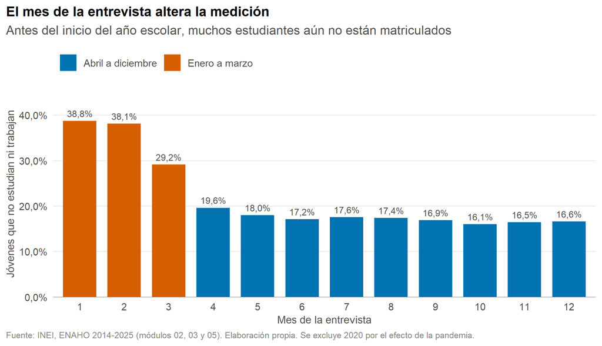

Figura 1: Tasa de nini según el mes de entrevista, sin corregir (promedio 2014-2025, excluye 2020)

```r
fig_mes <- ggplot(por_mes, aes(x = factor(mes), y = tasa, fill = periodo)) +
  geom_col(width = 0.75) +
  geom_text(aes(label = etiqueta_pct(tasa)), vjust = -0.6, size = 3, color = tinta_2) +
  scale_fill_manual(values = c("Enero a marzo" = col_naranja, "Abril a diciembre" = col_azul)) +
  scale_y_continuous(labels = etiqueta_pct, limits = c(0, max(por_mes$tasa) * 1.15),
                     expand = expansion(mult = c(0, 0.02))) +
  labs(
    title = "El mes de la entrevista altera la medición",
    subtitle = "Antes del inicio del año escolar, muchos estudiantes aún no están matriculados",
    x = "Mes de la entrevista", y = "Jóvenes que no estudian ni trabajan",
    caption = paste(fuente, "Se excluye 2020 por el efecto de la pandemia.")
  )
fig_mes
```

**Lectura.** Entre enero y marzo la tasa sin corregir es 18,0 puntos porcentuales más alta que entre abril y diciembre. No es que haya más ninis en verano: es que el instrumento los cuenta mal. La confirmación está en los propios datos, porque el INEI pregunta la razón de no estudiar: entre enero y marzo, el 24,3 % de quienes no están matriculados responde que está **de vacaciones**, frente a apenas 0,7 % en el resto del año.

Hay dos formas de tratarlo. Una es descartar enero, febrero y marzo, con lo que se pierde cerca de la cuarta parte de la muestra. La otra es **reclasificar como estudiante a quien declara explícitamente estar de vacaciones**, categoría que —según verificamos— existe con el mismo código en los doce años.

Elegimos la segunda, porque corrige la causa y no el síntoma, y porque conserva la muestra completa. La primera se reporta igual, en la tabla de robustez, para que se vea cuánto depende el resultado de este supuesto.

## 3.9 Muestra analítica y diseño muestral

**Ver código**

```r
gt_flujo <- tibble(
  Paso = c("1. Personas en el módulo de miembros del hogar",
           "2. Residentes habituales del hogar",
           "3. Residentes habituales de 15 a 29 años",
           "4. Con información válida de educación y empleo (muestra analítica)"),
  Casos = c(nrow(base), sum(base$residente), nrow(jovenes_todos), nrow(jovenes))
) |>
  mutate(`% del paso anterior` = 100 * Casos / lag(Casos)) |>
  gt(rowname_col = "Paso") |>
  tab_source_note(paste("Nota.", "ENAHO 2014-2025, acumulado de los doce años.")) |>
  fmt_number(columns = Casos, decimals = 0, sep_mark = " ") |>
  fmt_number(columns = `% del paso anterior`, decimals = 1, dec_mark = ",") |>
  sub_missing(missing_text = "—") |>
  tab_source_note(fuente) |>
  estilo_gt()
gt_flujo
```

Tabla 5: Construcción de la muestra analítica, del total de personas encuestadas

|  | Casos | % del paso anterior |
| --- | --- | --- |
| 1. Personas en el módulo de miembros del hogar | 1 512 409 | — |
| 2. Residentes habituales del hogar | 1 403 132 | 92,8 |
| 3. Residentes habituales de 15 a 29 años | 306 576 | 21,8 |
| 4. Con información válida de educación y empleo (muestra analítica) | 305 906 | 99,8 |

Nota. ENAHO 2014-2025, acumulado de los doce años.  
Fuente: INEI, ENAHO 2014-2025 (módulos 02, 03 y 05). Elaboración propia.

**Declaración del diseño muestral complejo**

```r
# La ENAHO no es una muestra aleatoria simple: ignorar su diseño subestima los
# errores estándar. El conglomerado es la unidad primaria de muestreo y el estrato
# geográfico el estrato; ambos se interactúan con el año porque los códigos de
# conglomerado se reutilizan entre años (y en 2014 tienen 4 dígitos, no 6).
diseno <- jovenes |>
  mutate(upm          = as.integer(factor(paste(anio, conglome))),
         estrato_anio = as.integer(factor(paste(anio, estrato_muestral))),
         nini_num     = as.numeric(nini)) |>
  as_survey_design(ids = upm, strata = estrato_anio, weights = peso, nest = TRUE)
```

Las estimaciones se ponderan con **`fac500a`**, el factor de expansión del módulo de empleo, que corresponde a la población de 14 años y más ajustada por sexo y grupos de edad (Instituto Nacional de Estadística e Informática, 2025). Es el coherente con el indicador, porque la condición de ocupación proviene de `ocu500`, que vive en ese módulo. No usamos `factora07`, el factor del módulo de educación: ponderar una unión de módulos con el factor de uno de ellos mezclaría poblaciones de referencia distintas.

# 4 Análisis

## 4.1 Evolución nacional

**Ver código**

```r
tasa_anual <- diseno |>
  group_by(anio) |>
  summarise(tasa = survey_mean(nini_num, vartype = "ci", level = 0.95) * 100,
            n = unweighted(n()),
            n_nini = unweighted(sum(nini))) |>
  rename(tasa_inf = tasa_low, tasa_sup = tasa_upp)

poblacion <- jovenes |> group_by(anio) |>
  summarise(poblacion = sum(peso), .groups = "drop")

serie <- tasa_anual |>
  left_join(poblacion, by = "anio") |>
  mutate(nini_miles = tasa / 100 * poblacion / 1000)

v <- function(a, col = "tasa") serie[[col]][serie$anio == a]
```

**Ver código**

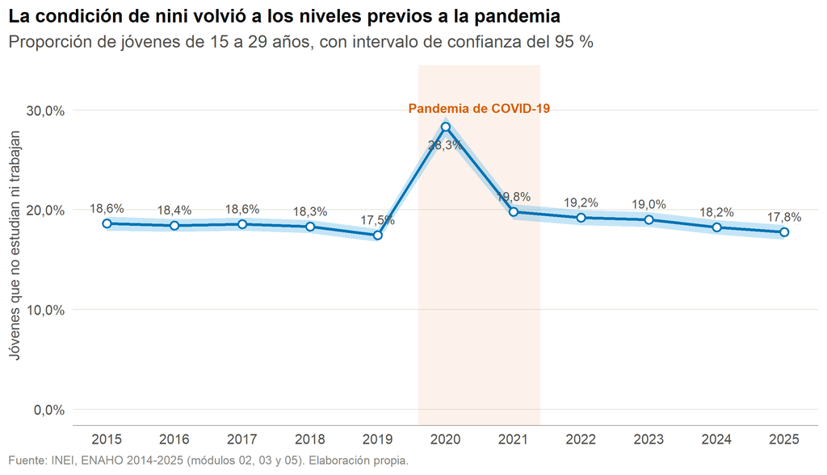

Figura 2: Proporción de jóvenes de 15 a 29 años que no estudian ni trabajan, 2015-2025

```r
serie_grafico <- serie |> filter(anio >= 2015)

fig_tendencia <- ggplot(serie_grafico, aes(x = anio, y = tasa)) +
  annotate("rect", xmin = 2019.6, xmax = 2021.4, ymin = -Inf, ymax = Inf,
           fill = col_naranja, alpha = 0.08) +
  annotate("text", x = 2020.5, y = max(serie_grafico$tasa_sup) * 1.03,
           label = "Pandemia de COVID-19", color = col_naranja, size = 3.1, fontface = "bold") +
  geom_ribbon(aes(ymin = tasa_inf, ymax = tasa_sup), fill = col_azul_claro, alpha = 0.35) +
  geom_line(color = col_azul, linewidth = 0.9) +
  geom_point(shape = 21, fill = "white", color = col_azul, size = 2.2, stroke = 0.9) +
  geom_text(aes(label = etiqueta_pct(tasa)),
            vjust = if_else(serie_grafico$anio %in% c(2020), 2.4, -1.2),
            size = 3, color = tinta_2) +
  scale_x_continuous(breaks = 2015:2025) +
  scale_y_continuous(labels = etiqueta_pct,
                     limits = c(0, max(serie_grafico$tasa_sup) * 1.12)) +
  labs(
    title = "La condición de nini volvió a los niveles previos a la pandemia",
    subtitle = "Proporción de jóvenes de 15 a 29 años, con intervalo de confianza del 95 %",
    x = NULL, y = "Jóvenes que no estudian ni trabajan", caption = fuente
  )
fig_tendencia
```

**Lectura.** La serie cuenta tres historias encadenadas. Entre 2015 y 2019 hay una **mejora lenta pero sostenida**, de 18,6 % a 17,5 %. En **2020 la serie se rompe**: la tasa salta a 28,3 %, es decir 10,9 puntos porcentuales por encima del año anterior, lo que equivale a unos 0,98 millones de jóvenes adicionales en esa condición. Después viene una **recuperación gradual** que lleva cinco años: en 2025 la tasa es de 17,8 %, con lo que la serie apenas regresa al nivel previo a la pandemia —17,5 % en 2019— sin conseguir bajar de él. La diferencia entre ambos años es de 0,3 puntos porcentuales y, como muestra la Tabla 7, no se distingue de cero.

**Ver código**

```r
gt_nacional <- serie |>
  filter(anio >= 2015) |>
  select(anio, tasa, tasa_inf, tasa_sup, nini_miles, n, n_nini) |>
  gt() |>
  tab_source_note(paste("Nota.", "Población de 15 a 29 años, Perú, 2015-2025.")) |>
  tab_spanner(label = "Tasa (%) e IC 95 %", columns = c(tasa, tasa_inf, tasa_sup)) |>
  tab_spanner(label = "Muestra", columns = c(n, n_nini)) |>
  cols_label(anio = "Año", tasa = "Estimación", tasa_inf = "IC inf.", tasa_sup = "IC sup.",
             nini_miles = "Miles de jóvenes", n = "Total", n_nini = "Nini") |>
  fmt_number(columns = c(tasa, tasa_inf, tasa_sup), decimals = 1, dec_mark = ",") |>
  fmt_number(columns = nini_miles, decimals = 0, sep_mark = " ") |>
  fmt_number(columns = c(n, n_nini), decimals = 0, sep_mark = " ") |>
  tab_style(style = cell_fill(color = "#faede3"),
            locations = cells_body(rows = anio == 2020)) |>
  tab_source_note(paste(fuente, "Intervalos de confianza al 95 % calculados con el diseño muestral complejo.")) |>
  estilo_gt()
gt_nacional
```

Tabla 6: Tasa de nini, población estimada y tamaño de muestra, 2015-2025

| Año | Tasa (%) e IC 95 % Estimación | Tasa (%) e IC 95 % IC inf. | Tasa (%) e IC 95 % IC sup. | Miles de jóvenes | Muestra Total | Muestra Nini |
| --- | --- | --- | --- | --- | --- | --- |
| 2015 | 18,6 | 17,9 | 19,3 | 1 496 | 26 253 | 4 761 |
| 2016 | 18,4 | 17,8 | 19,1 | 1 495 | 28 808 | 5 223 |
| 2017 | 18,6 | 17,9 | 19,2 | 1 499 | 26 805 | 4 904 |
| 2018 | 18,3 | 17,7 | 19,0 | 1 477 | 27 741 | 4 854 |
| 2019 | 17,5 | 16,8 | 18,1 | 1 405 | 25 457 | 4 325 |
| 2020 | 28,3 | 27,3 | 29,4 | 2 387 | 26 116 | 6 747 |
| 2021 | 19,8 | 19,0 | 20,6 | 1 685 | 24 657 | 4 493 |
| 2022 | 19,2 | 18,5 | 20,0 | 1 634 | 24 599 | 4 400 |
| 2023 | 19,0 | 18,3 | 19,8 | 1 621 | 23 888 | 4 253 |
| 2024 | 18,2 | 17,5 | 19,0 | 1 558 | 23 034 | 4 047 |
| 2025 | 17,8 | 17,0 | 18,5 | 1 517 | 22 168 | 3 678 |

Nota. Población de 15 a 29 años, Perú, 2015-2025.  
Fuente: INEI, ENAHO 2014-2025 (módulos 02, 03 y 05). Elaboración propia. Intervalos de confianza al 95 % calculados con el diseño muestral complejo.

**Ver código**

```r
# Con un único regresor dicotómico, el coeficiente de la regresión ES la diferencia
# de proporciones, y survey::svyglm le calcula el error estándar correcto.
comparar <- function(a1, a2) {
  d <- diseno |> filter(anio %in% c(a1, a2)) |> mutate(anio_f = factor(anio))
  m <- survey::svyglm(nini_num ~ anio_f, design = d)
  ic <- confint(m)[2, ]
  tibble(Comparación = paste(a1, "a", a2),
         Diferencia = coef(m)[2] * 100,
         `IC inf.` = ic[1] * 100, `IC sup.` = ic[2] * 100,
         p = summary(m)$coefficients[2, 4])
}

pruebas <- bind_rows(comparar(2015, 2019), comparar(2019, 2020),
                     comparar(2020, 2021), comparar(2019, 2025),
                     comparar(2015, 2025), comparar(2024, 2025))

gt_pruebas <- pruebas |>
  gt() |>
  tab_source_note(paste("Nota.", "Diferencia en puntos porcentuales entre pares de años.")) |>
  fmt_number(columns = c(Diferencia, `IC inf.`, `IC sup.`), decimals = 2, dec_mark = ",") |>
  # APA 7: los valores p no llevan cero a la izquierda porque no pueden superar 1
  fmt_number(columns = p, decimals = 3, dec_mark = ",") |>
  text_replace(pattern = "^0,", replacement = ",", locations = cells_body(columns = p)) |>
  sub_small_vals(columns = p, threshold = 0.001, small_pattern = "< ,001") |>
  cols_label(p = md("*p*")) |>
  tab_source_note(paste(fuente, "Estimadas con survey::svyglm sobre el diseño muestral complejo.")) |>
  estilo_gt()
gt_pruebas
```

Tabla 7: Significancia estadística de los cambios entre años seleccionados

| Comparación | Diferencia | IC inf. | IC sup. | *p* |
| --- | --- | --- | --- | --- |
| 2015 a 2019 | −1,17 | −2,13 | −0,21 | ,017 |
| 2019 a 2020 | 10,88 | 9,68 | 12,09 | < ,001 |
| 2020 a 2021 | −8,54 | −9,83 | −7,25 | < ,001 |
| 2019 a 2025 | 0,30 | −0,67 | 1,28 | ,544 |
| 2015 a 2025 | −0,87 | −1,89 | 0,15 | ,095 |
| 2024 a 2025 | −0,49 | −1,52 | 0,54 | ,348 |

Nota. Diferencia en puntos porcentuales entre pares de años.  
Fuente: INEI, ENAHO 2014-2025 (módulos 02, 03 y 05). Elaboración propia. Estimadas con survey::svyglm sobre el diseño muestral complejo.

**Lectura.** La mejora entre 2015 y 2019 es modesta pero estadísticamente distinguible de cero. El salto de 2019 a 2020 y la caída de 2020 a 2021 son, con enorme diferencia, los movimientos más grandes de la serie. La comparación que mejor resume la década es **2015 contra 2025**: la tasa bajó 0,9 puntos porcentuales, un cambio que **no alcanza significancia estadística** (*p* = ,095). Después de once años y de una pandemia, no podemos afirmar que el país esté mejor que al inicio de la serie.

## 4.2 Las cuatro condiciones de actividad

Mirar solo la tasa de nini oculta de dónde vienen los cambios. Las cuatro combinaciones posibles entre estudiar y trabajar cuentan una historia más completa.

**Ver código**

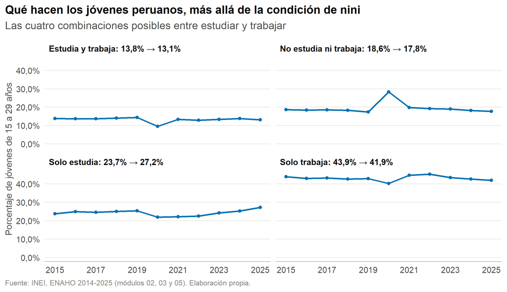

Figura 3: Distribución de los jóvenes de 15 a 29 años según condición de actividad, 2015-2025

```r
condiciones <- jovenes |>
  filter(anio >= 2015) |>
  count(anio, condicion, wt = peso) |>
  group_by(anio) |>
  mutate(pct = 100 * n / sum(n)) |>
  ungroup()

# Los títulos de panel llevan los valores extremos: evita etiquetar cada línea
titulos <- condiciones |>
  filter(anio %in% c(2015, 2025)) |>
  select(condicion, anio, pct) |>
  pivot_wider(names_from = anio, values_from = pct, names_prefix = "a") |>
  mutate(titulo = paste0(condicion, ": ", etiqueta_pct(a2015), " → ", etiqueta_pct(a2025)))

fig_condicion <- condiciones |>
  left_join(titulos |> select(condicion, titulo), by = "condicion") |>
  ggplot(aes(x = anio, y = pct)) +
  geom_line(color = col_azul, linewidth = 0.8) +
  geom_point(size = 1.2, color = col_azul) +
  facet_wrap(~ titulo, nrow = 2) +
  scale_x_continuous(breaks = seq(2015, 2025, 2)) +
  scale_y_continuous(labels = etiqueta_pct, limits = c(0, NA)) +
  labs(
    title = "Qué hacen los jóvenes peruanos, más allá de la condición de nini",
    subtitle = "Las cuatro combinaciones posibles entre estudiar y trabajar",
    x = NULL, y = "Porcentaje de jóvenes de 15 a 29 años", caption = fuente
  )
fig_condicion
```

## 4.3 ¿En qué grupos se concentra?

**Ver código**

```r
tasa_sexo <- diseno |>
  group_by(anio, sexo) |>
  summarise(tasa = survey_mean(nini_num, vartype = "ci", level = 0.95) * 100) |>
  rename(tasa_inf = tasa_low, tasa_sup = tasa_upp) |>
  filter(anio >= 2015)

# Mujeres menos hombres, indexando por etiqueta: depender del orden de las filas
# es justamente como se cuelan los errores de signo.
brecha_sexo <- function(a) {
  t <- tasa_sexo |> filter(anio == a)
  t$tasa[t$sexo == "Mujeres"] - t$tasa[t$sexo == "Hombres"]
}
brechas <- tibble(anio = 2015:2025) |> mutate(brecha = map_dbl(anio, brecha_sexo))
brecha_2015 <- brecha_sexo(2015)
brecha_2025 <- brecha_sexo(2025)
brecha_2020 <- brecha_sexo(2020)
# Rango de la brecha en la década previa a 2025, para mostrar lo estable que fue
brechas_hasta_2024 <- brechas |> filter(anio <= 2024) |> pull(brecha)
```

**Ver código**

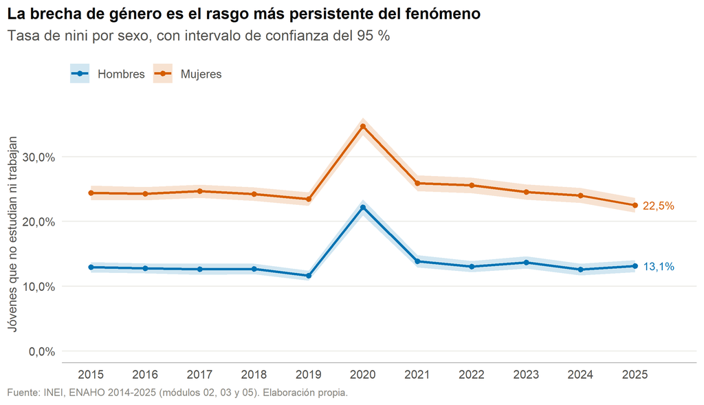

Figura 4: Tasa de nini por sexo, 2015-2025

```r
fig_sexo <- ggplot(tasa_sexo, aes(x = anio, y = tasa, color = sexo, fill = sexo)) +
  geom_ribbon(aes(ymin = tasa_inf, ymax = tasa_sup), alpha = 0.18, color = NA) +
  geom_line(linewidth = 0.9) +
  geom_point(size = 1.6) +
  geom_text(data = tasa_sexo |> filter(anio == 2025),
            aes(label = etiqueta_pct(tasa)), hjust = -0.25, size = 3.2, show.legend = FALSE) +
  scale_color_manual(values = c("Hombres" = col_azul, "Mujeres" = col_naranja)) +
  scale_fill_manual(values = c("Hombres" = col_azul, "Mujeres" = col_naranja)) +
  scale_x_continuous(breaks = 2015:2025, limits = c(2015, 2025.6)) +
  scale_y_continuous(labels = etiqueta_pct, limits = c(0, NA)) +
  labs(
    title = "La brecha de género es el rasgo más persistente del fenómeno",
    subtitle = "Tasa de nini por sexo, con intervalo de confianza del 95 %",
    x = NULL, y = "Jóvenes que no estudian ni trabajan", caption = fuente
  )
fig_sexo
```

**Lectura.** Lo primero que llama la atención es la **estabilidad**: entre 2015 y 2024 la brecha se mantuvo siempre entre 10,9 y 12,5 puntos porcentuales, sin tendencia. Una década entera sin movimiento.

La pandemia **no cerró la brecha, la ensanchó**: en 2020 llegó a 12,5 puntos, su valor más alto de la serie. El cierre de la economía golpeó a los varones, pero golpeó más a las mujeres.

El único quiebre aparece en 2025, cuando la diferencia baja a 9,4 puntos, impulsada por una caída en la tasa femenina. Es el mejor registro de la serie, pero es **un solo año**: con los datos disponibles no se puede distinguir todavía si es el comienzo de un cambio o una fluctuación. Habrá que mirar 2026.

**Ver código**

```r
calcular_grupo <- function(variable) {
  jovenes |>
    filter(anio %in% c(2015, 2025), !is.na(.data[[variable]])) |>
    group_by(anio, categoria = as.character(.data[[variable]])) |>
    summarise(tasa = 100 * weighted.mean(nini, peso), n = n(), .groups = "drop") |>
    mutate(dimension = variable)
}

grupos <- bind_rows(
  calcular_grupo("sexo"), calcular_grupo("grupo_edad"),
  calcular_grupo("area"), calcular_grupo("region"),
  calcular_grupo("nivel_educativo")
) |>
  mutate(dimension = recode(dimension,
    sexo = "Sexo", grupo_edad = "Edad", area = "Área",
    region = "Región", nivel_educativo = "Nivel educativo"
  ) |> factor(levels = c("Sexo", "Edad", "Área", "Región", "Nivel educativo")))

grupos_ancho <- grupos |>
  select(dimension, categoria, anio, tasa) |>
  pivot_wider(names_from = anio, values_from = tasa, names_prefix = "a") |>
  mutate(cambio = a2025 - a2015)
```

**Ver código**

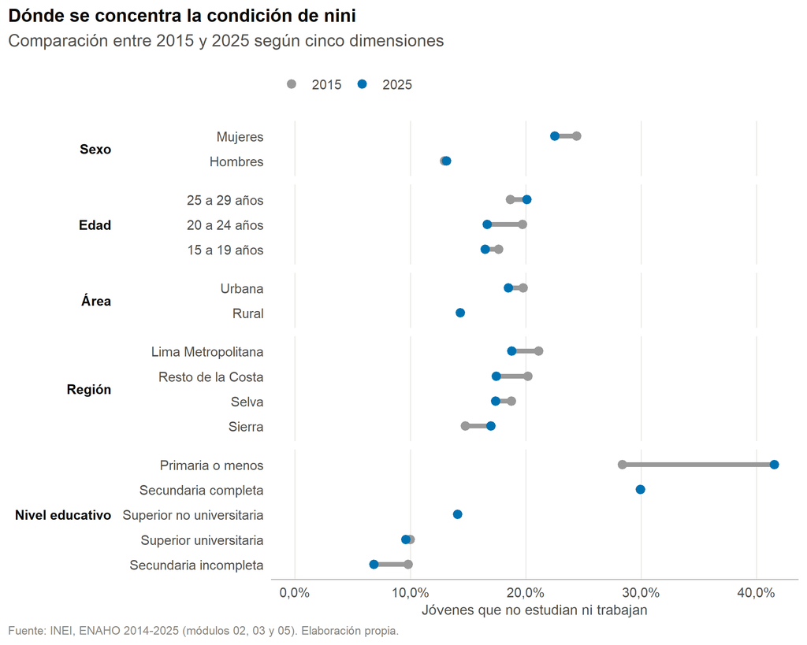

Figura 5: Tasa de nini por grupo, 2015 frente a 2025

```r
orden <- grupos_ancho |> arrange(dimension, a2025) |> pull(categoria)

fig_grupos <- grupos_ancho |>
  mutate(categoria = factor(categoria, levels = unique(orden))) |>
  ggplot(aes(y = categoria)) +
  geom_segment(aes(x = a2015, xend = a2025, yend = categoria),
               color = col_gris, linewidth = 1.6) +
  geom_point(aes(x = a2015, color = "2015"), size = 2.6) +
  geom_point(aes(x = a2025, color = "2025"), size = 2.6) +
  facet_grid(dimension ~ ., scales = "free_y", space = "free_y", switch = "y") +
  scale_color_manual(values = c("2015" = col_gris, "2025" = col_azul)) +
  scale_x_continuous(labels = etiqueta_pct, limits = c(0, NA)) +
  labs(
    title = "Dónde se concentra la condición de nini",
    subtitle = "Comparación entre 2015 y 2025 según cinco dimensiones",
    x = "Jóvenes que no estudian ni trabajan", y = NULL, caption = fuente
  ) +
  theme(panel.grid.major.x = element_line(color = grilla, linewidth = 0.3),
        panel.grid.major.y = element_blank(),
        strip.placement = "outside",
        strip.text.y.left = element_text(angle = 0, hjust = 1, face = "bold"))
fig_grupos
```

**Ver código**

```r
gt_grupos <- grupos_ancho |>
  arrange(dimension, desc(a2025)) |>
  select(dimension, categoria, a2015, a2025, cambio) |>
  gt(groupname_col = "dimension") |>
  tab_source_note(paste("Nota.", "Jóvenes de 15 a 29 años, comparación entre los extremos de la serie.")) |>
  cols_label(categoria = "", a2015 = "2015 (%)", a2025 = "2025 (%)",
             cambio = "Cambio (p.p.)") |>
  fmt_number(columns = c(a2015, a2025, cambio), decimals = 1, dec_mark = ",") |>
  tab_style(style = cell_text(color = col_naranja, weight = "bold"),
            locations = cells_body(columns = cambio, rows = cambio > 1)) |>
  tab_style(style = cell_text(color = col_azul, weight = "bold"),
            locations = cells_body(columns = cambio, rows = cambio < -1)) |>
  tab_source_note(paste(fuente, "En naranja los grupos que empeoraron más de un punto; en azul los que mejoraron más de un punto.")) |>
  estilo_gt()
gt_grupos
```

Tabla 8: Tasa de nini por grupo, 2015 y 2025, y cambio en puntos porcentuales

|  | 2015 (%) | 2025 (%) | Cambio (p.p.) |
| --- | --- | --- | --- |
| Sexo |  |  |  |
| Mujeres | 24,4 | 22,5 | −1,9 |
| Hombres | 12,9 | 13,1 | 0,2 |
| Edad |  |  |  |
| 25 a 29 años | 18,7 | 20,1 | 1,4 |
| 20 a 24 años | 19,7 | 16,7 | −3,1 |
| 15 a 19 años | 17,7 | 16,5 | −1,2 |
| Área |  |  |  |
| Urbana | 19,8 | 18,5 | −1,3 |
| Rural | 14,3 | 14,3 | 0,0 |
| Región |  |  |  |
| Lima Metropolitana | 21,1 | 18,8 | −2,3 |
| Resto de la Costa | 20,2 | 17,4 | −2,7 |
| Selva | 18,7 | 17,4 | −1,4 |
| Sierra | 14,8 | 17,0 | 2,2 |
| Nivel educativo |  |  |  |
| Primaria o menos | 28,4 | 41,5 | 13,2 |
| Secundaria completa | 29,9 | 29,9 | 0,0 |
| Superior no universitaria | 14,1 | 14,1 | −0,0 |
| Superior universitaria | 10,0 | 9,6 | −0,4 |
| Secundaria incompleta | 9,8 | 6,8 | −3,0 |

Nota. Jóvenes de 15 a 29 años, comparación entre los extremos de la serie.  
Fuente: INEI, ENAHO 2014-2025 (módulos 02, 03 y 05). Elaboración propia. En naranja los grupos que empeoraron más de un punto; en azul los que mejoraron más de un punto.

**Lectura.** Tres patrones se destacan. Primero, **el sexo domina sobre cualquier otra dimensión**: la diferencia entre mujeres y hombres es mayor que la que separa a cualquier par de regiones o de áreas. Segundo, **el grupo de 25 a 29 años es el único que empeoró** en la década, mientras que el de 20 a 24 mejoró de forma clara. Tercero, **la Sierra es la única región que retrocedió**, en contraste con la mejora de Lima Metropolitana y del resto de la Costa.

La fila de «Primaria o menos» exige cautela: su tasa sube con fuerza, pero es un grupo que se achica año a año a medida que se expande la cobertura educativa. Lo que aumenta no es necesariamente el riesgo de cada persona, sino la desventaja relativa de un grupo cada vez más seleccionado.

## 4.4 El nivel educativo hay que leerlo por edad

**Ver código**

```r
educ_edad <- jovenes |>
  filter(anio == 2025, !is.na(nivel_educativo)) |>
  group_by(nivel_educativo, grupo_edad) |>
  summarise(tasa = 100 * weighted.mean(nini, peso),
            estudia_pct = 100 * weighted.mean(estudia, peso),
            .groups = "drop")

gt_educ_edad <- educ_edad |>
  select(nivel_educativo, grupo_edad, tasa) |>
  pivot_wider(names_from = grupo_edad, values_from = tasa) |>
  gt() |>
  tab_source_note(paste("Nota.", "Tasa de nini (%) por nivel educativo alcanzado y grupo de edad, 2025.")) |>
  cols_label(nivel_educativo = "Nivel educativo alcanzado") |>
  fmt_number(columns = -nivel_educativo, decimals = 1, dec_mark = ",") |>
  tab_source_note(paste(fuente, "El nivel educativo de quien aún estudia está en curso, no completo.")) |>
  estilo_gt()
gt_educ_edad
```

Tabla 9: Tasa de nini según nivel educativo, dentro de cada grupo de edad (2025)

| Nivel educativo alcanzado | 15 a 19 años | 20 a 24 años | 25 a 29 años |
| --- | --- | --- | --- |
| Primaria o menos | 46,0 | 39,6 | 40,7 |
| Secundaria incompleta | 2,7 | 21,0 | 27,2 |
| Secundaria completa | 41,9 | 25,3 | 22,9 |
| Superior no universitaria | 3,1 | 13,1 | 17,3 |
| Superior universitaria | 4,1 | 7,2 | 13,4 |

Nota. Tasa de nini (%) por nivel educativo alcanzado y grupo de edad, 2025.  
Fuente: INEI, ENAHO 2014-2025 (módulos 02, 03 y 05). Elaboración propia. El nivel educativo de quien aún estudia está en curso, no completo.

**Lectura.** Esta tabla corrige una lectura equivocada que la tabla anterior invita a hacer. A simple vista, «Secundaria incompleta» aparece con una tasa de nini bajísima, lo que sugeriría que abandonar la secundaria protege. Es un espejismo: entre los 15 y los 19 años, el 94,4 % de quienes tienen secundaria incompleta **sigue estudiando**, sencillamente porque están cursándola. Su nivel educativo no está incompleto: está *en curso*.

Cuando se mira dentro del grupo de 25 a 29 años, donde la trayectoria educativa ya terminó, aparece el gradiente limpio y monótono que esperábamos: desde 40,7 % entre quienes tienen primaria o menos hasta 13,4 % entre quienes completaron estudios universitarios. **La educación superior reduce a menos de un tercio la probabilidad de estar en esta condición.**

## 4.5 Qué hacen los jóvenes nini

**Ver código**

```r
situacion <- jovenes |>
  filter(anio == 2025, nini) |>
  count(sexo, situacion_nini, wt = peso) |>
  group_by(sexo) |>
  mutate(pct = 100 * n / sum(n)) |>
  ungroup()

situacion_total <- jovenes |>
  filter(anio == 2025, nini) |>
  count(situacion_nini, wt = peso) |>
  mutate(pct = 100 * n / sum(n))

pct_de <- function(etiqueta, datos = situacion_total) datos$pct[datos$situacion_nini == etiqueta]
pct_sexo <- function(etiqueta, s) {
  situacion$pct[situacion$situacion_nini == etiqueta & situacion$sexo == s]
}
```

**Ver código**

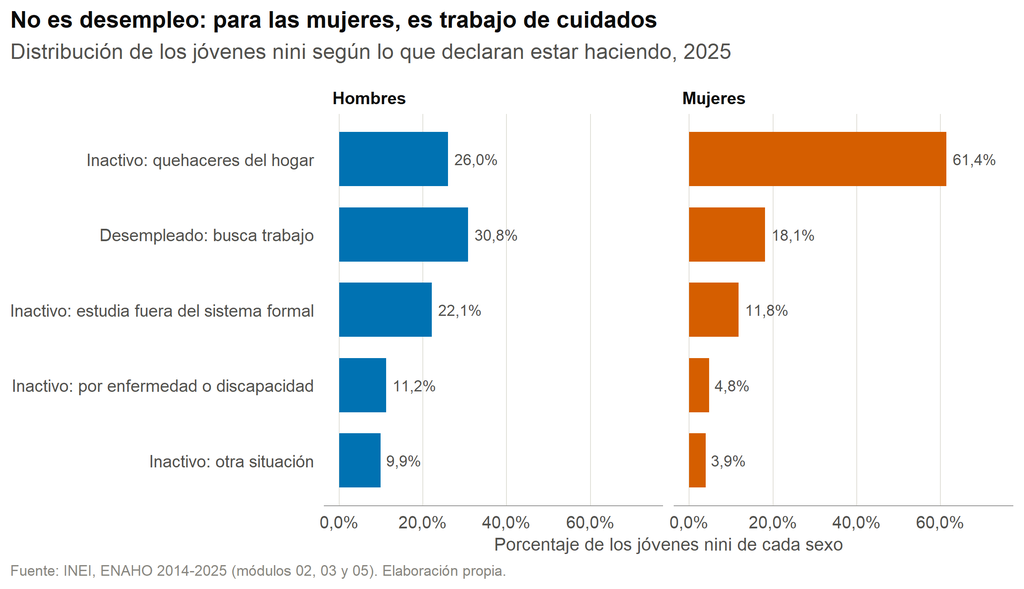

Figura 6: Situación de los jóvenes que no estudian ni trabajan, por sexo (2025)

```r
fig_situacion <- situacion |>
  mutate(situacion_nini = fct_reorder(situacion_nini, pct, .fun = max)) |>
  ggplot(aes(x = pct, y = situacion_nini, fill = sexo)) +
  geom_col(width = 0.72, show.legend = FALSE) +
  geom_text(aes(label = etiqueta_pct(pct)), hjust = -0.15, size = 3, color = tinta_2) +
  facet_wrap(~ sexo) +
  scale_fill_manual(values = c("Hombres" = col_azul, "Mujeres" = col_naranja)) +
  scale_x_continuous(labels = etiqueta_pct, limits = c(0, max(situacion$pct) * 1.2)) +
  labs(
    title = "No es desempleo: para las mujeres, es trabajo de cuidados",
    subtitle = "Distribución de los jóvenes nini según lo que declaran estar haciendo, 2025",
    x = "Porcentaje de los jóvenes nini de cada sexo", y = NULL, caption = fuente
  ) +
  theme(panel.grid.major.x = element_line(color = grilla, linewidth = 0.3),
        panel.grid.major.y = element_blank())
fig_situacion
```

**Lectura.** Este es el gráfico que más cambia la interpretación del problema. Solo el 22,9 % de los jóvenes nini está desempleado en sentido estricto, es decir buscando trabajo activamente. La categoría dominante es otra: el 48,1 % se dedica a los **quehaceres del hogar**.

Y ese promedio esconde una asimetría brutal. Entre las mujeres nini, el 61,4 % se dedica a tareas del hogar; entre los hombres nini, apenas el 26,0 %. A la inversa, el 30,8 % de los varones nini busca trabajo, frente al 18,1 % de las mujeres.

La conclusión de política es directa: **la brecha de género en la condición de nini no es principalmente un problema de demanda de empleo, sino de distribución del trabajo de cuidados.** Una política centrada solo en intermediación laboral difícilmente la mueva.

**Ver código**

```r
gt_situacion <- situacion |>
  select(sexo, situacion_nini, pct) |>
  pivot_wider(names_from = sexo, values_from = pct) |>
  left_join(situacion_total |> select(situacion_nini, Total = pct), by = "situacion_nini") |>
  arrange(desc(Total)) |>
  gt() |>
  tab_source_note(paste("Nota.", "Distribución porcentual dentro de cada sexo, 2025.")) |>
  cols_label(situacion_nini = "Situación") |>
  fmt_number(columns = -situacion_nini, decimals = 1, dec_mark = ",") |>
  tab_source_note(paste(fuente, "La condición de desocupado proviene de ocu500; el resto de las categorías, de p546.")) |>
  estilo_gt()
gt_situacion
```

Tabla 10: Situación de los jóvenes nini por sexo, 2025 (porcentaje de cada columna)

| Situación | Hombres | Mujeres | Total |
| --- | --- | --- | --- |
| Inactivo: quehaceres del hogar | 26,0 | 61,4 | 48,1 |
| Desempleado: busca trabajo | 30,8 | 18,1 | 22,9 |
| Inactivo: estudia fuera del sistema formal | 22,1 | 11,8 | 15,6 |
| Inactivo: por enfermedad o discapacidad | 11,2 | 4,8 | 7,2 |
| Inactivo: otra situación | 9,9 | 3,9 | 6,2 |

Nota. Distribución porcentual dentro de cada sexo, 2025.  
Fuente: INEI, ENAHO 2014-2025 (módulos 02, 03 y 05). Elaboración propia. La condición de desocupado proviene de ocu500; el resto de las categorías, de p546.

## 4.6 La dimensión territorial

**Ver código**

```r
# Se agrupan dos años por extremo para que ningún departamento quede con muestras
# demasiado pequeñas.
dep <- jovenes |>
  filter(anio %in% c(2015, 2016, 2024, 2025)) |>
  mutate(periodo = if_else(anio <= 2016, "2015-2016", "2024-2025")) |>
  group_by(departamento, periodo) |>
  summarise(tasa = 100 * weighted.mean(nini, peso), n = n(), .groups = "drop")

dep_ancho <- dep |>
  select(departamento, periodo, tasa) |>
  pivot_wider(names_from = periodo, values_from = tasa) |>
  mutate(cambio = `2024-2025` - `2015-2016`)

n_min_dep <- min(dep$n)

# Extremos, calculados y no escritos a mano, para que el texto no quede desfasado
dep_orden <- dep_ancho |> arrange(desc(`2024-2025`))
top3    <- head(dep_orden, 3)
bottom3 <- tail(dep_orden, 3) |> arrange(`2024-2025`)
peor_cambio  <- dep_ancho |> slice_max(cambio, n = 1)
mejor_cambio <- dep_ancho |> slice_min(cambio, n = 1)
lista <- function(x) paste(x, collapse = ", ")
```

**Ver código**

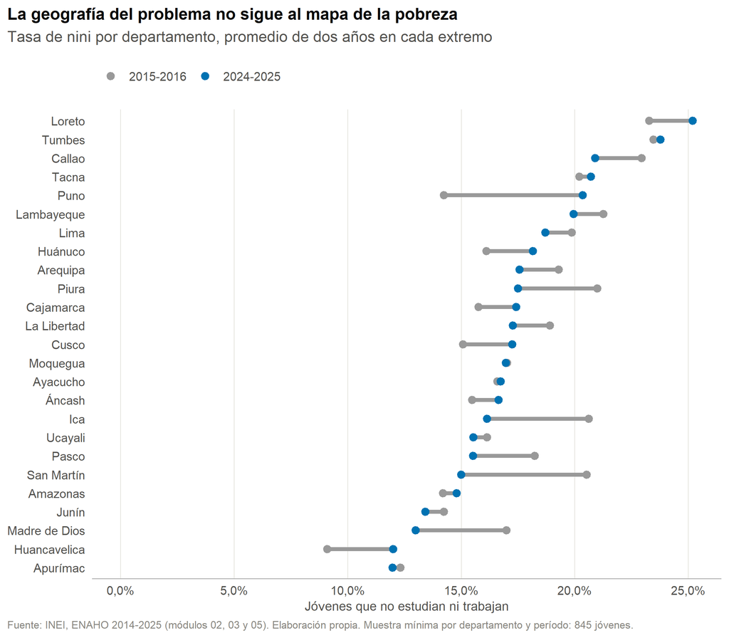

Figura 7: Tasa de nini por departamento, 2015-2016 frente a 2024-2025

```r
fig_departamentos <- dep_ancho |>
  mutate(departamento = fct_reorder(departamento, `2024-2025`)) |>
  ggplot(aes(y = departamento)) +
  geom_segment(aes(x = `2015-2016`, xend = `2024-2025`, yend = departamento),
               color = col_gris, linewidth = 1.5) +
  geom_point(aes(x = `2015-2016`, color = "2015-2016"), size = 2.4) +
  geom_point(aes(x = `2024-2025`, color = "2024-2025"), size = 2.4) +
  scale_color_manual(values = c("2015-2016" = col_gris, "2024-2025" = col_azul)) +
  scale_x_continuous(labels = etiqueta_pct, limits = c(0, NA)) +
  labs(
    title = "La geografía del problema no sigue al mapa de la pobreza",
    subtitle = "Tasa de nini por departamento, promedio de dos años en cada extremo",
    x = "Jóvenes que no estudian ni trabajan", y = NULL,
    caption = paste(fuente, "Muestra mínima por departamento y período:", f0(n_min_dep), "jóvenes.")
  ) +
  theme(panel.grid.major.x = element_line(color = grilla, linewidth = 0.3),
        panel.grid.major.y = element_blank())
fig_departamentos
```

**Lectura.** Lo primero que conviene decir es lo que **no** muestran los datos: no hay una correspondencia simple entre pobreza departamental y condición de nini. Las tasas más altas de 2024-2025 están en Loreto, Tumbes, Callao (25,2 %, 23,8 % y 20,9 %), un grupo heterogéneo que reúne a la Amazonía más pobre, a un departamento costero de frontera y a una provincia enteramente urbana. Las más bajas están en Apurímac, Huancavelica, Madre de Dios (12,0 %, 12,0 % y 13,0 %), e incluyen dos de los departamentos más pobres del país.

Ese último dato es el que obliga a tener cuidado. La lectura tentadora —que la pobreza «protege»— es falsa. La explicación más plausible es que **en las economías rurales de subsistencia los jóvenes se incorporan tempranamente al trabajo agrícola o familiar**, muchas veces sin remuneración y en condiciones precarias. El indicador los cuenta como ocupados, así que no aparecen como nini. **Una tasa baja no significa bienestar: puede señalar otra forma de desventaja que este indicador no captura.**

Los movimientos extremos de la década también valen la pena: Puno es el que más empeoró (6,1 puntos porcentuales) y San Martín el que más mejoró (-5,5 puntos). Con muestras departamentales de alrededor de 845 jóvenes por período, estas cifras tienen bastante más incertidumbre que las nacionales y conviene leerlas como señales, no como mediciones finas.

## 4.7 Robustez: ¿cuánto dependen los resultados de nuestras decisiones?

**Ver código**

```r
# Definición estricta NEET: también excluye a quienes reciben alguna capacitación
# fuera del sistema formal (ODS 8.6.1 incluye "training", no solo educación).
cod_cetpro <- codigo_de("p313", "tecnico productiv")

robustez <- jovenes |>
  mutate(
    recibe_capacitacion = coalesce(p313 == cod_cetpro, FALSE) |
                          coalesce(t313a == cod_cetpro, FALSE) |
                          coalesce(p546 == cod_estudiando, FALSE),
    nini_sin_correccion = !estudia_formal & !trabaja,
    nini_neet_estricto  = !(estudia | recibe_capacitacion) & !trabaja,
    nini_solo_matricula = !(p306 == 1 | de_vacaciones) & !trabaja
  ) |>
  group_by(anio) |>
  summarise(
    `Principal` = 100 * weighted.mean(nini, peso),
    `Sin corregir vacaciones` = 100 * weighted.mean(nini_sin_correccion, peso),
    `Solo abril a diciembre` = 100 * weighted.mean(nini_sin_correccion[mes >= 4], peso[mes >= 4]),
    `15 a 24 años (ODS 8.6.1)` = 100 * weighted.mean(nini[p208a <= 24], peso[p208a <= 24]),
    `Excluye capacitación` = 100 * weighted.mean(nini_neet_estricto, peso),
    `Estudia = solo matriculado` = 100 * weighted.mean(nini_solo_matricula, peso),
    .groups = "drop"
  ) |>
  filter(anio >= 2015)

gt_robustez <- robustez |>
  gt() |>
  tab_source_note(paste("Nota.", "Tasa de nini (%) bajo seis criterios alternativos.")) |>
  cols_label(anio = "Año") |>
  fmt_number(columns = -anio, decimals = 1, dec_mark = ",") |>
  tab_style(style = cell_fill(color = "#e3eff7"),
            locations = cells_body(columns = Principal)) |>
  tab_source_note(paste(fuente, "En azul la definición utilizada en todo el reporte.")) |>
  estilo_gt()
gt_robustez
```

Tabla 11: Tasa de nini bajo seis definiciones alternativas

| Año | Principal | Sin corregir vacaciones | Solo abril a diciembre | 15 a 24 años (ODS 8.6.1) | Excluye capacitación | Estudia = solo matriculado |
| --- | --- | --- | --- | --- | --- | --- |
| 2015 | 18,6 | 21,3 | 17,6 | 18,6 | 15,3 | 18,2 |
| 2016 | 18,4 | 20,9 | 17,4 | 18,0 | 15,0 | 17,9 |
| 2017 | 18,6 | 21,6 | 17,6 | 18,1 | 15,2 | 18,0 |
| 2018 | 18,3 | 21,8 | 16,7 | 18,3 | 15,0 | 17,8 |
| 2019 | 17,5 | 20,9 | 16,0 | 16,6 | 14,3 | 17,1 |
| 2020 | 28,3 | 32,1 | 30,0 | 27,2 | 26,1 | 26,5 |
| 2021 | 19,8 | 23,0 | 18,1 | 19,0 | 17,4 | 19,4 |
| 2022 | 19,2 | 22,2 | 18,3 | 19,0 | 16,2 | 18,7 |
| 2023 | 19,0 | 22,8 | 18,0 | 18,5 | 16,0 | 18,5 |
| 2024 | 18,2 | 21,5 | 17,2 | 17,2 | 15,2 | 17,7 |
| 2025 | 17,8 | 21,3 | 16,5 | 16,6 | 14,9 | 17,1 |

Nota. Tasa de nini (%) bajo seis criterios alternativos.  
Fuente: INEI, ENAHO 2014-2025 (módulos 02, 03 y 05). Elaboración propia. En azul la definición utilizada en todo el reporte.

**Lectura.** El nivel de la tasa se mueve según la definición, pero **la forma de la serie no cambia**: todas las variantes muestran la misma mejora lenta hasta 2019, el mismo salto en 2020 y la misma recuperación posterior. Las conclusiones del reporte no dependen de la definición elegida.

Dos comparaciones merecen comentario:

- **Sin corregir vacaciones**, la tasa sube unos 3,2 puntos en promedio. Es la magnitud del artefacto que describimos en la sección Sección 3.8.
- **Excluyendo la capacitación**, la tasa baja alrededor de 3,0 puntos. Esta variante es la más cercana al indicador 8.6.1 de los ODS, que excluye no solo a quienes estudian sino también a quienes reciben formación. La diferencia corresponde sobre todo a jóvenes que declaran estar estudiando en el módulo de empleo pero no figuran matriculados en el sistema formal: academias, cursos cortos o centros técnico-productivos. Mantenemos la definición basada en matrícula y asistencia formal como principal, por ser la comparable con las estadísticas oficiales del INEI, pero **la cifra alternativa debe tenerse presente al comparar con fuentes internacionales**.

# 5 Resultados y conclusiones

**1. La década terminó donde empezó.** La proporción de jóvenes de 15 a 29 años que no estudian ni trabajan pasó de 18,6 % en 2015 a 17,8 % en 2025: apenas 0,9 puntos porcentuales de descenso en once años, una diferencia que ni siquiera alcanza significancia estadística (*p* = ,095). La mejora que se venía acumulando hasta 2019 fue borrada por la pandemia, y cinco años después la serie apenas había vuelto a ese nivel.

**2. La pandemia fue una ruptura, no una inflexión.** En 2020 la tasa alcanzó 28,3 %, 10,9 puntos por encima de 2019. Pero el análisis por condición de actividad muestra que el fenómeno fue, sobre todo, **destrucción de empleo juvenil**: quienes estudiaban y trabajaban perdieron el trabajo, y quienes solo trabajaban quedaron sin nada.

**3. Ser mujer es, por lejos, el factor más asociado a esta condición.** La brecha se mantuvo clavada entre 10,9 y 12,5 puntos porcentuales durante toda la década, y la pandemia la ensanchó en lugar de cerrarla. Solo en 2025 baja a 9,4 puntos, un dato alentador pero de un único año. Ninguna otra dimensión —edad, área, región— produce diferencias siquiera cercanas a esa magnitud.

**4. El problema no es principalmente desempleo: es trabajo de cuidados no remunerado.** Solo el 22,9 % de los jóvenes nini busca trabajo activamente, mientras que el 48,1 % se dedica a los quehaceres del hogar. Entre las mujeres nini esa proporción llega al 61,4 %. Es el hallazgo con implicancias más claras de política pública.

**5. La educación superior protege, pero hay que medirlo bien.** Dentro del grupo de 25 a 29 años, donde la trayectoria educativa ya concluyó, la tasa va de 40,7 % entre quienes tienen primaria o menos a 13,4 % entre los universitarios.

**6. La geografía no sigue al mapa de la pobreza.** Dos de los departamentos más pobres del país figuran entre los de menor tasa, probablemente porque sus jóvenes se incorporan temprano al trabajo agrícola o familiar, muchas veces sin remuneración. No estar en condición de nini no equivale a estar bien, y este es el límite más serio del indicador.

## 5.1 Qué se puede y qué no se puede concluir

Este análisis es **descriptivo**. Identifica con precisión cuántos jóvenes están en esta condición, cómo evolucionó la cifra y en qué grupos se concentra. Eso es lo que se puede afirmar.

Lo que **no** se puede afirmar es causalidad. Que las mujeres tengan tasas más altas no demuestra que el género *cause* la condición de nini: lo que muestran los datos es que las responsabilidades de cuidado, desigualmente distribuidas, se asocian fuertemente con ella. Tampoco se puede concluir que la educación superior *produzca* mejores resultados, porque quienes acceden a ella difieren de quienes no lo hacen en muchas otras dimensiones no observadas. Separar esos efectos exigiría un diseño distinto.

Tampoco se puede hablar de trayectorias individuales. Como explicamos en las limitaciones, el análisis compara cortes transversales anuales y no sigue a las mismas personas en el tiempo: no sabemos si se trata de los mismos jóvenes que permanecen años en esta condición o de personas distintas que entran y salen.

# 6 Limitaciones

1. **El INEI imputa parte de los datos.** La ficha técnica documenta que las variables cualitativas de los módulos de educación, salud y empleo se imputan mediante la técnica *Hot Deck* a los miembros del hogar que no informaron los tres módulos simultáneamente (Instituto Nacional de Estadística e Informática, 2025). Una fracción de los valores de `p306`, `p307` y `ocu500` es, por lo tanto, imputada y no declarada.
2. **La muestra tiene componente panel.** En 2025, 12 096 de las 36 594 viviendas encuestadas son panel. Los años no son muestras independientes, lo que implica tratar la serie como cortes transversales agrupados y no como seguimiento de personas. Las pruebas de hipótesis entre años asumen independencia y, en esa medida, son conservadoras en el sentido equivocado.
3. **2020 combina dos efectos.** Ese año la encuesta se levantó con modalidad mixta —presencial y telefónica— por la emergencia sanitaria. El salto de la serie mezcla un efecto real sobre empleo y educación con un posible efecto del modo de recolección, y no podemos separarlos.
4. **La definición es sensible al mes de entrevista.** Lo corregimos reclasificando a quienes declaran estar de vacaciones, pero el supuesto es el más influyente del trabajo. La tabla de robustez muestra su magnitud.
5. **Aparecen códigos nuevos a mitad de la serie** en `p203` (2018), `p301a` (2017) y `t313a` (2020). Las agrupaciones elegidas los absorben, pero las desagregaciones por parentesco y nivel educativo deben leerse con esa advertencia.
6. **No incorporamos pobreza ni ingresos del hogar.** Requiere el módulo Sumaria, que no descargamos. Es la extensión más valiosa que queda pendiente, porque permitiría distinguir si la condición de nini es un fenómeno de hogares pobres o transversal.
7. **El indicador no captura la calidad del empleo.** Un joven que trabaja diez horas semanales sin remuneración en el negocio familiar cuenta como ocupado. Eso explica buena parte del resultado territorial y advierte contra leer una tasa baja de nini como buena noticia.
8. **Nuestras cifras no son directamente comparables con otras compilaciones.** En la compilación regional del Banco Mundial (de Hoyos et al., 2016) el Perú aparece con la tasa más baja de América Latina —10,9 % para el tramo de 15 a 24 años, con datos de alrededor de 2013—, mientras que nuestra estimación para ese mismo tramo en 2015 es de 18,6 %. Parte de la brecha es atribuible a la definición —su criterio excluye a quienes reciben capacitación, y bajo ese criterio nuestra cifra baja a 15,3 %— y parte al año de referencia, pero **no logramos explicarla por completo**. Lo más probable es que intervengan además diferencias de armonización entre bases regionales y los microdatos originales del INEI. Dejamos constancia porque es un recordatorio de que la tasa de nini depende de decisiones metodológicas que no siempre se publican, y de que la nuestra sí está documentada paso a paso en este reporte.

**Qué haríamos con más tiempo.** Incorporar el módulo Sumaria para cruzar con pobreza; explotar el componente panel de la ENAHO para medir cuánto tiempo permanecen los jóvenes en esta condición; estimar un modelo logístico multivariado que permita separar el efecto de cada característica controlando por las demás; e incorporar la presencia de hijos pequeños en el hogar, que presumimos central para explicar la brecha de género.

# 7 Fuentes, declaración de aportes y uso de IA

## 7.1 Fuentes

Asencios, R., Perea, J., & Rosado, G. (2025). Hechos estilizados del mercado laboral peruano. *Revista Moneda*, (201), 69-77. https://www.bcrp.gob.pe/docs/Publicaciones/Revista-Moneda/moneda-201/moneda-201-11.pdf

Chacaltana, J., & Ruiz, C. (2012). El empleo juvenil en el Perú: diagnóstico y políticas. En C. Garavito & I. Muñoz (Eds.), *Empleo y protección social*. Fondo Editorial de la Pontificia Universidad Católica del Perú.

Congreso de la República del Perú. (2002). *Ley N.º 27802, Ley del Consejo Nacional de la Juventud*. Diario Oficial El Peruano.

de Hoyos, R., Rogers, H., & Székely, M. (2016). *Ninis en América Latina: 20 millones de jóvenes en búsqueda de oportunidades*. Banco Mundial. https://openknowledge.worldbank.org/handle/10986/22349

Instituto Nacional de Estadística e Informática. (2015). *Encuesta Nacional de Hogares sobre Condiciones de Vida y Pobreza 2015* [Ficha técnica]. INEI.

Instituto Nacional de Estadística e Informática. (2025). *Encuesta Nacional de Hogares 2025* [Ficha técnica]. Dirección Nacional de Censos y Encuestas, INEI.

Instituto Nacional de Estadística e Informática. (2026). *Encuesta Nacional de Hogares (ENAHO) 2014–2025* [Conjunto de datos]. https://proyectos.inei.gob.pe/microdatos/

Instituto Peruano de Economía. (2024). *Uno de cada cuatro jóvenes no logra mantener su empleo formal*. En alianza con El Comercio. https://ipe.org.pe/uno-de-cada-cuatro-jovenes-no-logra-mantener-su-empleo-formal/

Naciones Unidas. (2015). *Transformar nuestro mundo: la Agenda 2030 para el Desarrollo Sostenible* (Resolución A/RES/70/1). Asamblea General de las Naciones Unidas.

Okabe, M., & Ito, K. (2008). *Color universal design (CUD): How to make figures and presentations that are friendly to colorblind people*. J*Fly Data Depository for Drosophila Researchers. https://jfly.uni-koeln.de/color/

Organización Internacional del Trabajo. (1982). *Resolución sobre estadísticas de la población económicamente activa, del empleo, del desempleo y del subempleo* [Resolución de la XIII Conferencia Internacional de Estadísticos del Trabajo].

Székely, M., & Karver, J. (2021). Youth out of school and out of work in Latin America: A cohort approach. *International Journal of Educational Development*, *80*, 102294. https://doi.org/10.1016/j.ijedudev.2020.102294

Tokman, V. E. (2010). Desempleo juvenil en América Latina: causas, consecuencias y políticas. En B. Kliksberg (Ed.), *Es difícil ser joven en América Latina: los desafíos abiertos* (pp. 107-138). Sudamericana.

## 7.2 Reproducibilidad

Todas las figuras usan la paleta de **Okabe e Ito** (2008), construida para que sus colores sigan siendo distinguibles bajo las formas más frecuentes de daltonismo. El par que más trabaja en este reporte —azul `#0072B2` y bermellón `#D55E00`— mantiene una diferencia perceptual (ΔE 2000) de 50 en visión tricromática y de 63 simulando deuteranopía: la separación no solo se conserva, aumenta. El gris `#999999` marca el año de referencia en los gráficos de pendiente, donde su separación frente al azul es menor (ΔE 27) pero el color no es la única pista: el segmento que une ambos puntos ya indica por sí solo la dirección del cambio.

Todo el análisis está contenido en este documento. Para reproducirlo:

1. Clonar el [repositorio del proyecto en GitHub](https://github.com/LuisGuevaraVega/Tarea_R_G7) y abrir `Tarea_R_G7.Rproj`.
2. Ejecutar `scripts/01_descargar_enaho.R` si no están los datos en `data/raw/`.
3. Renderizar este archivo con `quarto render docs/reporte_ninis.qmd`.

La primera compilación lee los 36 archivos de microdatos y tarda alrededor de un minuto; las siguientes usan el extracto cacheado en `data/processed/`. El caché se invalida solo si cambian los años o la lista de variables.

Documentación complementaria: `docs/registro_metodologico.md` (decisiones y verificaciones) y `docs/diccionario_variables.md` (codificación de cada variable, año por año).

## 7.3 Declaración de aportes

| Integrante | Aporte |
| --- | --- |
| Luis Guevara | Exploración inicial de los microdatos, definición operativa del indicador y revisión de la sección de análisis |
| Rodrigo Norabuena | Pipeline de importación y limpieza, auditoría de codificación, diseño muestral y construcción de tablas y gráficos |
| Marco Virú | Revisión metodológica, redacción de la introducción, interpretación de resultados y de las limitaciones |

## 7.4 Uso de herramientas de inteligencia artificial

Sí se usaron herramientas de IA. Se empleó **Claude Code (Anthropic)** en las siguientes tareas:

- **Auditoría de la codificación de las variables.** Se usó para escribir el código que extrae las etiquetas de Stata de los 36 archivos y las compara entre años. El resultado —qué variables cambian y cuáles no— fue **verificado por el grupo** contra los diccionarios y fichas técnicas oficiales del INEI incluidos en los propios archivos comprimidos.
- **Estructuración del pipeline de importación.** Ayudó a resolver problemas técnicos concretos: la lectura selectiva de columnas desde los ZIP, la inconsistencia de la estructura interna de los archivos y el manejo del cambio de formato Stata en 2025.
- **Redacción y edición del documento.** Se usó para ordenar la exposición y pulir la redacción utilizando **Grammarly**.

Lo que **el grupo verificó directamente**:

- La definición operativa de nini, contrastada con la ficha técnica del INEI.
- El criterio de área urbana y rural, confirmado con la cita textual de las fichas técnicas de 2015 y de 2025, que están incluidas en los archivos descargados.
- Las cifras de la serie nacional, comparadas de forma independiente con un cálculo paralelo hecho por otro integrante del grupo con un pipeline distinto; los valores coinciden.
- La interpretación de todos los resultados y las conclusiones, que son del grupo.